# 薪资透视：从数据看职场的薪水法则

# 1 数据预处理

## 1.1 加载必要的包

```r
library(tidyverse)
library(readxl)
library(writexl)
library(dplyr)
```

## 1.2 读取原始数据

```r
# 读取原始数据
data_raw <- read_excel("data/data_origin.xlsx")
head(data_raw)
```

```
## # A tibble: 6 × 10
##   职位  位置    年薪 福利  已有工作经验 学历   公司行业        融资阶段 公司规模
##   <chr> <chr>  <dbl> <lgl> <chr>        <chr>  <chr>           <chr>    <chr>
## 1 CFO   广东   36    FALSE 5年以上      本科   服务业          未知     100-499
## 2 CFO   北京   45    FALSE 5年以上      本科   金融            未知     100-499
## 3 CFO   山东   24.6  FALSE 经验不限     研究生 互联网/IT/电子… 未融资   100以下
## 4 CFO   上海    8.25 TRUE  1-3年        本科   互联网/IT/电子… A轮      100以下
## 5 CFO   浙江  102    FALSE 5年以上      大专   金融            未知     100以下
## 6 CFO   上海  162.   TRUE  5年以上      研究生 互联网/IT/电子… C轮      100-499
## # ℹ 1 more variable: 职业类别 <chr>
```

## 1.3 年薪对数化处理

为了改善数据分布的偏态性,对年薪进行对数变换:

```r
# 对年薪进行对数变换
data_raw <- data_raw %>%
  mutate(log_salary = log(年薪))

# 查看转换后的基本统计信息
summary(data_raw$log_salary)
```

```
##    Min. 1st Qu.  Median    Mean 3rd Qu.    Max.
## -0.6024  1.7918  2.0541  2.1651  2.4849  5.7236
```

## 1.4 更改职业、地区类别、公司行业与融资阶段

```r
data_raw <- data_raw %>%
  mutate(职业类别 = case_when(
    职业类别 %in% c("技术与工程类", "商务与管理类") ~ "商务与工程类",
    职业类别 %in% c("媒体与创意类", "教育与培训类") ~ "媒体与培训类",
    职业类别 %in% c("销售与市场类", "服务与支持类") ~ "销售与服务类",
    TRUE ~ 职业类别
  ))
```

```r
data_raw <- data_raw %>%
  mutate(位置 = case_when(
    位置 %in% c("北京", "天津", "上海", "江苏", "浙江", "山东", "福建", "台湾") ~ "东部地区",
    位置 %in% c("湖北", "湖南", "安徽", "江西", "河北", "内蒙古", "河南", "山西") ~ "中部地区",
    位置 %in% c("新疆", "西藏", "青海", "四川", "云南", "陕西", "重庆", "甘肃", "宁夏") ~ "西部地区",
    位置 %in% c("贵州", "广西", "广东", "深圳", "海南") ~ "南部地区",
    位置 %in% c("黑龙江", "吉林", "辽宁") ~ "东北地区",
    TRUE ~ "南部地区"
  ))
```

```r
data_raw <- data_raw %>%
  mutate(公司行业 = case_when(
    公司行业 %in% c("互联网/IT/电子/通信", "金融") ~ "金融互联网",
    公司行业 %in% c("广告/传媒/文化/体育", "教育培训") ~ "媒体教培",
    公司行业 %in% c("制药/医疗", "交通/物流/贸易/零售", "政府/非盈利机构/其他", "能源/化工/环保") ~ "公共服务",
    公司行业 %in% c("专业服务", "房地产/建筑", "服务业", "消费品") ~ "商业服务",
    公司行业 %in% c("汽车", "机械/制造") ~ "机械制造",
    TRUE ~ 公司行业
  ))
```

```r
data_raw <- data_raw %>%
  mutate(融资阶段 = case_when(
    融资阶段 %in% c("A轮", "B轮", "C轮", "D轮及以上") ~ "正在融资",
    融资阶段 %in% c("天使轮", "未融资") ~ "准备融资",
    TRUE ~ 融资阶段
  ))
```

## 1.5 保存处理后的数据

```r
# 保存处理后的数据
write_xlsx(data_raw, "data/data.xlsx")
```

# 2 描述性统计

## 2.1 Settings

加载必要的包

```r
library(ggplot2)
library(readxl)
library(patchwork)
library(tidyverse)
library(showtext)
```

图像设置：

```r
# 蓝色系调色板
job_palette <- c(
  "A" = "#4A90E2", # 深蓝 - 用于主要类别
  "B" = "#5DADE2", # 蓝色 - 用于次要类别
  "C" = "#85C1E9", # 浅蓝 - 用于第三级类别
  "D" = "#AED6F1", # 浅蓝 - 用于背景或次要信息
  "E" = "#D6EAF8" # 浅蓝白 - 用于补充信息
)

# 主题自定义函数
theme_job_analysis <- function() {
  theme_minimal() +
    theme(
      # 字体设置
      text = element_text(family = theme_font),

      # 标题设置
      plot.title = element_text(
        size = 16,
        face = "bold",
        hjust = 0.5,
        color = job_palette["A"],
        margin = margin(b = 20)
      ),

      # 副标题设置
      plot.subtitle = element_text(
        size = 12,
        hjust = 0.5,
        color = job_palette["B"],
        margin = margin(b = 10)
      ),

      # 轴标题设置
      axis.title = element_text(
        size = 12,
        color = job_palette["A"],
        margin = margin(t = 10, b = 10)
      ),

      # 轴文本设置
      axis.text = element_text(
        size = 10,
        color = "#666666"
      ),

      # 网格线设置
      panel.grid.major = element_line(
        color = "#EEEEEE",
        size = 0.2
      ),
      panel.grid.minor = element_blank(),

      # 图例设置
      legend.title = element_text(
        size = 11,
        color = job_palette["A"]
      ),
      legend.text = element_text(
        size = 10,
        color = "#666666"
      ),
      legend.position = "right",

      # 背景设置
      plot.background = element_rect(
        fill = "white",
        color = NA
      ),
      panel.background = element_rect(
        fill = "white",
        color = NA
      ),

      # 边距设置
      plot.margin = margin(t = 20, r = 20, b = 20, l = 20)
    )
}


# 启用中文字体支持
theme_font <- "STSongti-SC-Black"
font_add(family = "STSongti-SC-Black", regular = "data/STSongti-SC-Black.ttf")
```

## 2.2 因变量描述性统计：年薪的处理

### 2.2.1 年薪箱线图、直方图统计

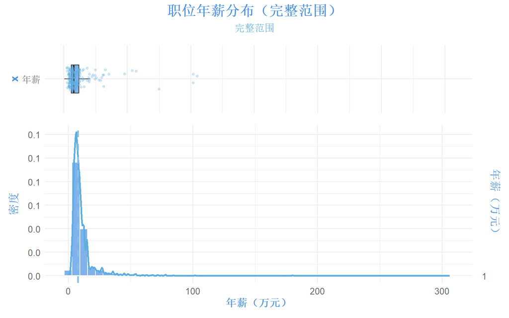

```r
# 创建基础箱线图函数，添加采样点参数
create_boxplot <- function(data_raw, y_limit = NULL) {
  ggplot(data_raw, aes(x = "年薪", y = 年薪)) +
    geom_boxplot(
      fill = job_palette["A"],
      alpha = 0.7,
      width = 0.5,
      outlier.shape = NA
    ) +
    geom_jitter(
      data = data_raw[sample(1:nrow(data_raw), min(nrow(data_raw) * 0.1, 200)), ],
      color = job_palette["B"],
      alpha = 0.3,
      width = 0.2,
      size = 1
    ) +
    labs(y = "年薪（万元）") +
    coord_flip() +
    theme_minimal() +
    theme(
      text = element_text(family = theme_font), # 默认中文字体
      axis.text = element_text(size = 10, color = "#666666", family = theme_font), # 坐标轴刻度
      axis.title = element_text(size = 12, face = "bold", color = job_palette["A"], family = theme_font), # 坐标轴标题
      axis.text.x = element_blank(), # 隐藏 x 轴刻度
      axis.title.x = element_blank(), # 隐藏 x 轴标题
      axis.text.y = element_text(size = 10, family = theme_font), # y 轴刻度中文显示
      plot.title = element_text(size = 16, face = "bold", color = job_palette["A"], family = theme_font), # 图标题
      plot.subtitle = element_text(size = 12, color = job_palette["B"], family = theme_font) # 副标题
    ) +
    scale_y_continuous(
      breaks = scales::pretty_breaks(n = 6), # 主坐标轴等间隔视觉距离
      labels = scales::number_format(accuracy = 0.1), # 对数坐标标签
      sec.axis = sec_axis(
        trans = ~ exp(.), # 次坐标轴转换回实际年薪
        name = "年薪（万元）",
        breaks = exp(scales::pretty_breaks(n = 6)(range(data_raw$log_salary))),
        labels = function(x) format(round(x), scientific = FALSE, big.mark = ",")
      )
    )
}

# 创建直方图函数
create_histogram <- function(data_raw, x_limit = NULL) {
  ggplot(data_raw, aes(x = 年薪)) +
    geom_histogram(
      aes(y = ..density..),
      fill = job_palette["A"],
      color = "white",
      bins = 50,
      alpha = 0.7
    ) +
    geom_density(
      color = job_palette["B"],
      linewidth = 1
    ) +
    geom_vline(
      xintercept = median(data_raw$年薪, na.rm = TRUE),
      color = job_palette["C"],
      linetype = "dashed",
      linewidth = 1
    ) +
    labs(
      x = "年薪（万元）",
      y = "密度"
    ) +
    theme_minimal() +
    theme(
      text = element_text(family = theme_font), # 默认中文字体
      axis.text = element_text(size = 10, color = "#666666", family = theme_font), # 坐标轴刻度
      axis.title = element_text(size = 12, face = "bold", color = job_palette["A"], family = theme_font), # 坐标轴标题
      axis.text.x = element_text(size = 10, family = theme_font), # x 轴刻度中文显示
      axis.text.y = element_text(size = 10, family = theme_font), # y 轴刻度中文显示
      plot.title = element_text(size = 16, face = "bold", color = job_palette["A"], family = theme_font), # 图标题
      plot.subtitle = element_text(size = 12, color = job_palette["B"], family = theme_font) # 副标题
    ) +
    scale_y_continuous(
      breaks = scales::pretty_breaks(n = 6), # 主坐标轴等间隔视觉距离
      labels = scales::number_format(accuracy = 0.1), # 对数坐标标签
      sec.axis = sec_axis(
        trans = ~ exp(.), # 次坐标轴转换回实际年薪
        name = "年薪（万元）",
        breaks = exp(scales::pretty_breaks(n = 6)(range(data_raw$log_salary))),
        labels = function(x) format(round(x), scientific = FALSE, big.mark = ",")
      )
    )
}

# 计算统计量用于限定范围的图
salary_stats <- summary(data_raw$年薪)
salary_iqr <- IQR(data_raw$年薪, na.rm = TRUE)
salary_upper <- salary_stats[5] + 1.5 * salary_iqr
create_combined_plot <- function(data_raw, limits = NULL, title_suffix) {
  boxplot <- create_boxplot(data_raw, limits)
  histogram <- create_histogram(data_raw, limits)

  # 使用 patchwork 合并图形
  combined_plot <- boxplot + histogram +
    plot_layout(heights = c(0.3, 0.7)) +
    plot_annotation(
      title = paste0("职位年薪分布", title_suffix),
      subtitle = if (is.null(limits)) {
        "完整范围"
      } else {
        paste0("显示范围：0-", round(salary_upper, 1), "万元")
      },
      theme = theme(
        plot.title = element_text(
          size = 16,
          face = "bold",
          hjust = 0.5,
          color = job_palette["A"],
          family = theme_font
        ),
        plot.subtitle = element_text(
          size = 12,
          hjust = 0.5,
          color = job_palette["B"],
          family = theme_font
        )
      )
    )

  return(combined_plot)
}

# 生成两种图：完整范围和限定范围
combined_plot1 <- create_combined_plot(data_raw, NULL, "（完整范围）")
combined_plot2 <- create_combined_plot(data_raw, c(0, salary_upper), "（基本统计范围）")

# 显示图形
print(combined_plot1)
```

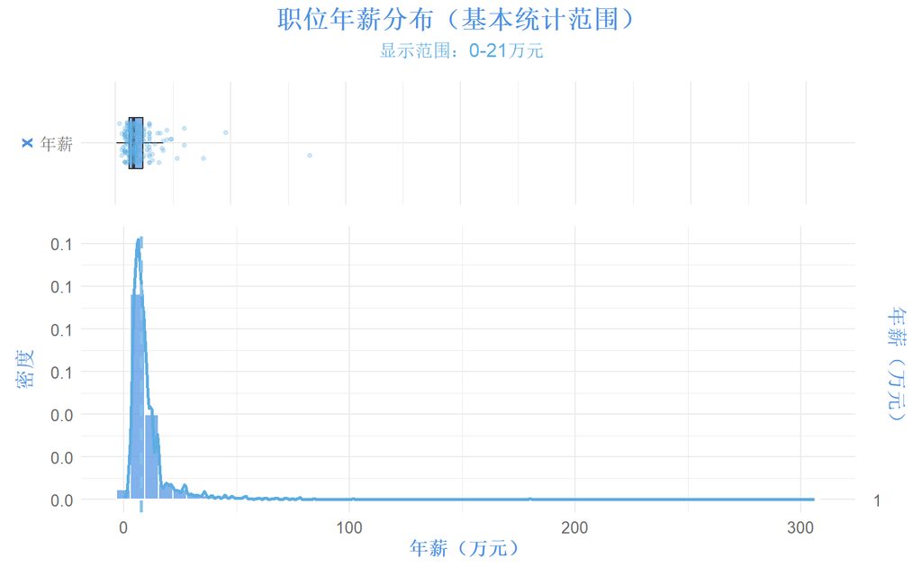

```r
print(combined_plot2)
```

图1：职位年薪分布（完整范围）

- 整体分布特征：该图展示了年薪的完整范围分布。大多数职位的年薪集中在较低区间，随着年薪的增大，职位数量迅速减少，形成了典型的右偏分布。年薪超过 200 万的职位较少，显示了较强的分布不均。
- 密度分布：从密度曲线可以看出，年薪的高峰值主要集中在较低的年薪区间（例如 10 万以下），密度随着年薪增大快速降低，说明绝大部分职位的年薪集中在低薪范围。

图2：职位年薪分布（基本统计范围）

总体分析

```r
# 查看薪资的基本统计信息
summary(data_raw$年薪)
```

```
##     Min.  1st Qu.   Median     Mean  3rd Qu.     Max.
##   0.5475   6.0000   7.8000  11.2779  12.0000 306.0000
```

### 2.2.2 年薪对数化处理

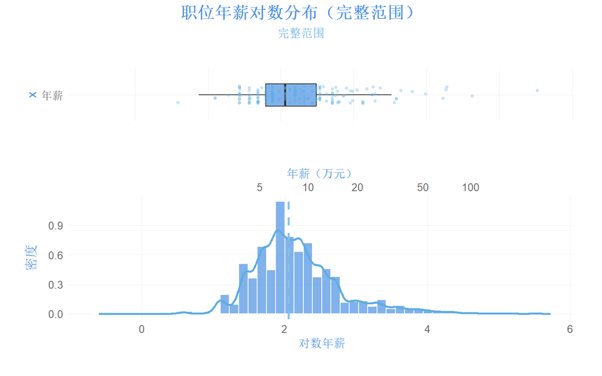

```r
# 创建对数年薪的箱线图函数
create_log_boxplot <- function(data, y_limit = NULL) {
  ggplot(data, aes(x = "年薪", y = log_salary)) +
    geom_boxplot(
      fill = job_palette["A"],
      alpha = 0.7,
      width = 0.5,
      outlier.shape = NA
    ) +
    geom_jitter(
      data = sample_n(data, min(nrow(data) * 0.1, 200)),
      color = job_palette["B"],
      alpha = 0.3,
      width = 0.2,
      size = 1
    ) +
    labs(y = "对数年薪") +
    coord_flip() +
    theme_job_analysis() +
    theme(
      axis.text.x = element_blank(),
      axis.title.x = element_blank()
    ) +
    scale_y_continuous(
      breaks = scales::pretty_breaks(n = 6), # 主坐标轴等间隔视觉距离
      labels = scales::number_format(accuracy = 0.1), # 对数坐标标签
      sec.axis = sec_axis(
        trans = ~ exp(.),
        name = "年薪（万元）",
        breaks = exp(scales::pretty_breaks(n = 6)(range(data_raw$log_salary))),
        labels = function(x) format(round(x), scientific = FALSE, big.mark = ",")
      )
    )
}

# 创建对数年薪的直方图函数
create_log_histogram <- function(data, x_limit = NULL) {
  ggplot(data, aes(x = log_salary)) +
    geom_histogram(
      aes(y = ..density..),
      fill = job_palette["A"],
      color = "white",
      bins = 50,
      alpha = 0.7
    ) +
    geom_density(
      color = job_palette["B"],
      linewidth = 1
    ) +
    geom_vline(
      xintercept = median(data$log_salary, na.rm = TRUE),
      color = job_palette["C"],
      linetype = "dashed",
      linewidth = 1
    ) +
    labs(
      x = "对数年薪",
      y = "密度"
    ) +
    theme_job_analysis() +
    # 添加次坐标轴显示原始年薪值
    scale_x_continuous(
      sec.axis = sec_axis(
        trans = ~ exp(.),
        name = "年薪（万元）",
        breaks = c(5, 10, 20, 50, 100),
        labels = function(x) format(x, scientific = FALSE, big.mark = ",")
      )
    )
}

# 计算对数年薪的基本统计量
log_salary_stats <- summary(data_raw$log_salary)
log_salary_iqr <- IQR(data_raw$log_salary, na.rm = TRUE)
log_salary_upper <- log_salary_stats[5] + 1.5 * log_salary_iqr

# 创建对数年薪的组合图
create_log_combined_plot <- function(data, limits = NULL, title_suffix) {
  boxplot <- create_log_boxplot(data, limits)
  histogram <- create_log_histogram(data, limits)

  boxplot / histogram +
    plot_layout(heights = c(0.3, 0.7)) +
    plot_annotation(
      title = paste0("职位年薪对数分布", title_suffix),
      subtitle = if (is.null(limits)) {
        "完整范围"
      } else {
        "基本统计范围"
      },
      theme = theme(
        plot.title = element_text(
          size = 16,
          face = "bold",
          hjust = 0.5,
          color = job_palette["A"],
          family = theme_font
        ),
        plot.subtitle = element_text(
          size = 12,
          hjust = 0.5,
          color = job_palette["B"],
          family = theme_font
        )
      )
    )
}

# 生成两种对数图：完整范围和限定范围
log_combined_plot1 <- create_log_combined_plot(data_raw, NULL, "（完整范围）")
log_combined_plot2 <- create_log_combined_plot(data_raw, c(log(1), log_salary_upper), "（基本统计范围）")

# 显示图形
print(log_combined_plot1)
```

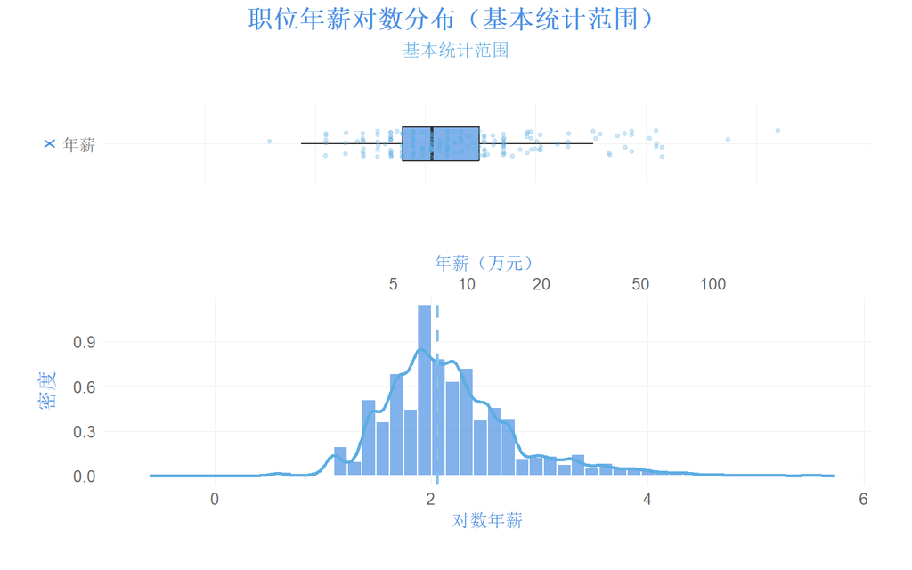

```r
print(log_combined_plot2)
```

在本次分析中，我们对年薪数据进行了对数变换，以改善模型的拟合效果，并从数据的分布和变量关系中获得更深刻的洞察。通过对数处理，年薪数据的分布显著优化，极大地减少了偏态和极端值的影响，使数据更接近正态分布。这一变换不仅有效降低了高薪职位对模型的偏倚影响，还缓解了回归分析中的异方差性问题，为模型假设的满足提供了更可靠的基础。

在结果解释上，对数变换后的模型输出可以更直观地理解为变量变化对薪资的比例影响，而非绝对值变化。这种比例解释符合实际场景的需求，为企业决策和政策制定提供了更有意义的参考依据。因此，对年薪数据的对数处理，不仅提高了分析的精确性，也提升了结果的实用价值和可解释性。

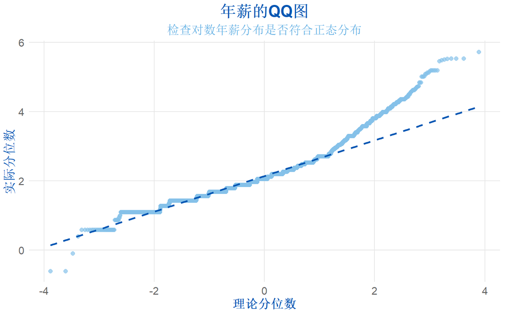

```r
# 绘制对数年薪的 QQ 图
p_qq <- ggplot(data_raw, aes(sample = log_salary)) +
  stat_qq(color = "#85C1E9", alpha = 0.7, size = 2) + # QQ 图点
  stat_qq_line(color = "#0056b3", linetype = "dashed", size = 1) + # QQ 图参考线
  labs(
    title = "年薪的QQ图",
    subtitle = "检查对数年薪分布是否符合正态分布",
    x = "理论分位数",
    y = "实际分位数"
  ) +
  theme_minimal() +
  theme(
    text = element_text(family = theme_font),
    plot.title = element_text(size = 18, hjust = 0.5, face = "bold", color = "#0056b3"),
    plot.subtitle = element_text(size = 14, hjust = 0.5, color = "#5DADE2"),
    axis.title.x = element_text(size = 14, face = "bold", color = "#0056b3"),
    axis.title.y = element_text(size = 14, face = "bold", color = "#0056b3"),
    axis.text.x = element_text(size = 12, color = "#666666"),
    axis.text.y = element_text(size = 12, color = "#666666"),
    panel.grid.major = element_line(color = "#E6E6E6"),
    panel.grid.minor = element_blank()
  )

print(p_qq)
```

总体而言，这张QQ图验证了对数变换的有效性，使得数据在大范围内更加接近正态分布，有助于提高模型假设的满足程度，为后续的回归分析和统计推断奠定了基础。

## 2.3 自变量描述性分析

### 2.3.1 统计基本描述性信息

```r
# 简单数据预览
head(data_raw)
```

```
## # A tibble: 6 × 11
##   职位  位置       年薪 福利  已有工作经验 学历   公司行业   融资阶段 公司规模
##   <chr> <chr>     <dbl> <lgl> <chr>        <chr>  <chr>      <chr>    <chr>
## 1 CFO   南部地区  36    FALSE 5年以上      本科   商业服务   未知     100-499
## 2 CFO   东部地区  45    FALSE 5年以上      本科   金融互联网 未知     100-499
## 3 CFO   东部地区  24.6  FALSE 经验不限     研究生 金融互联网 准备融资 100以下
## 4 CFO   东部地区   8.25 TRUE  1-3年        本科   金融互联网 正在融资 100以下
## 5 CFO   东部地区 102    FALSE 5年以上      大专   金融互联网 未知     100以下
## 6 CFO   东部地区 162.   TRUE  5年以上      研究生 金融互联网 正在融资 100-499
## # ℹ 2 more variables: 职业类别 <chr>, log_salary <dbl>
```

```r
str(data_raw)
```

```
## tibble [9,865 × 11] (S3: tbl_df/tbl/data.frame)
##  $ 职位        : chr [1:9865] "CFO" "CFO" "CFO" "CFO" ...
##  $ 位置        : chr [1:9865] "南部地区" "东部地区" "东部地区" "东部地区" ...
##  $ 年薪        : num [1:9865] 36 45 24.6 8.25 102 ...
##  $ 福利        : logi [1:9865] FALSE FALSE FALSE TRUE FALSE TRUE ...
##  $ 已有工作经验: chr [1:9865] "5年以上" "5年以上" "经验不限" "1-3年" ...
##  $ 学历        : chr [1:9865] "本科" "本科" "研究生" "本科" ...
##  $ 公司行业    : chr [1:9865] "商业服务" "金融互联网" "金融互联网" "金融互联网" ...
##  $ 融资阶段    : chr [1:9865] "未知" "未知" "准备融资" "正在融资" ...
##  $ 公司规模    : chr [1:9865] "100-499" "100-499" "100以下" "100以下" ...
##  $ 职业类别    : chr [1:9865] "商务与工程类" "商务与工程类" "商务与工程类" "商务与工程类" ...
##  $ log_salary  : num [1:9865] 3.58 3.81 3.2 2.11 4.62 ...
```

```r
# 统计基本描述性信息
summary(data_raw)
```

```
##      职位               位置                年薪             福利
##  Length:9865        Length:9865        Min.   :  0.5475   Mode :logical
##  Class :character   Class :character   1st Qu.:  6.0000   FALSE:5885
##  Mode  :character   Mode  :character   Median :  7.8000   TRUE :3980
##                                        Mean   : 11.2779
##                                        3rd Qu.: 12.0000
##                                        Max.   :306.0000
##  已有工作经验           学历             公司行业           融资阶段
##  Length:9865        Length:9865        Length:9865        Length:9865
##  Class :character   Class :character   Class :character   Class :character
##  Mode  :character   Mode  :character   Mode  :character   Mode  :character
##
##
##
##    公司规模           职业类别           log_salary
##  Length:9865        Length:9865        Min.   :-0.6024
##  Class :character   Class :character   1st Qu.: 1.7918
##  Mode  :character   Mode  :character   Median : 2.0541
##                                        Mean   : 2.1651
##                                        3rd Qu.: 2.4849
##                                        Max.   : 5.7236
```

### 2.3.2 x1=位置

```r
# 对城市等级统计职位数
city_level_summary <- data_raw %>%
  group_by(位置) %>%
  summarise(
    职位数量 = n(),
    平均年薪 = mean(年薪, na.rm = TRUE),
    中位年薪 = median(年薪, na.rm = TRUE)
  ) %>%
  arrange(desc(职位数量))
print(city_level_summary)
```

```
## # A tibble: 5 × 4
##   位置     职位数量 平均年薪 中位年薪
##   <chr>       <int>    <dbl>    <dbl>
## 1 东部地区     3431    14.7       9.6
## 2 中部地区     2675     8.53      7.2
## 3 南部地区     2026    10.8       7.8
## 4 西部地区     1234     9.46      7.2
## 5 东北地区      499     9.41      6.6
```

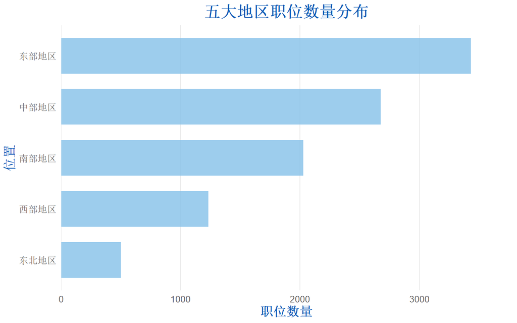

```r
# 只显示职位数量排名前30的城市
top_cities <- city_level_summary %>% slice_head(n = 30)

# 绘制优化后的柱状图
ggplot(top_cities, aes(x = reorder(位置, 职位数量), y = 职位数量)) +
  geom_bar(stat = "identity", fill = "#85C1E9", alpha = 0.8, width = 0.7) +
  coord_flip() +
  labs(
    title = "五大地区职位数量分布",
    x = "位置",
    y = "职位数量"
  ) +
  theme_minimal() +
  theme(
    text = element_text(family = theme_font),
    plot.title = element_text(size = 18, hjust = 0.5, face = "bold", color = "#0056b3"),
    axis.title.x = element_text(size = 14, face = "bold", color = "#0056b3"),
    axis.title.y = element_text(size = 14, face = "bold", color = "#0056b3"),
    axis.text.x = element_text(size = 10, color = "#666666"),
    axis.text.y = element_text(size = 10, color = "#666666"),
    panel.grid.major.y = element_blank(),
    panel.grid.minor = element_blank()
  ) +
  scale_y_continuous(expand = expansion(mult = c(0, 0.1)))
```

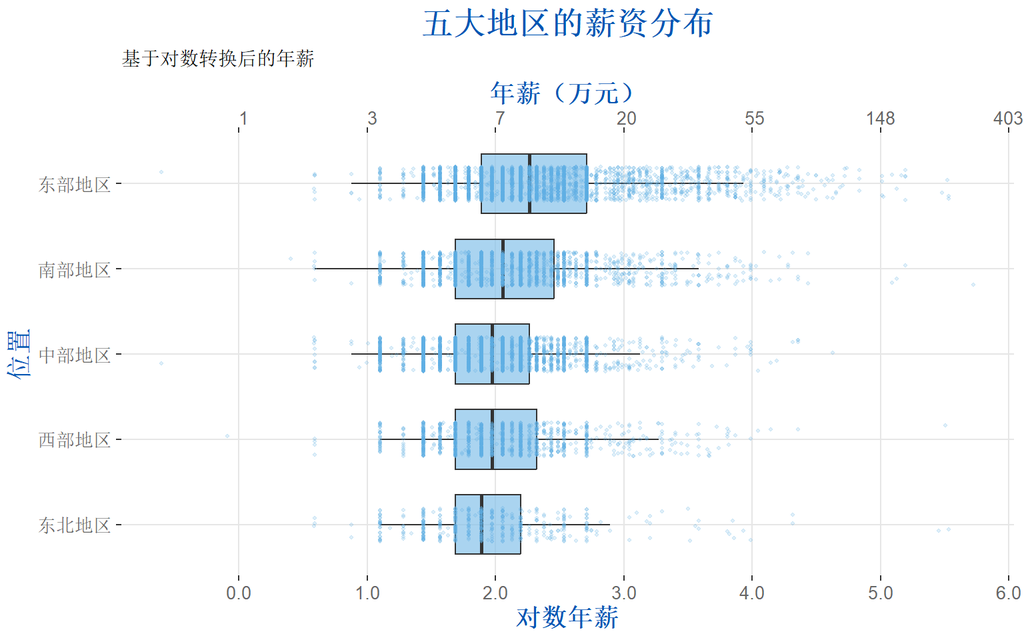

```r
p <- ggplot(
  data_raw,
  aes(x = reorder(位置, log_salary, FUN = median), y = log_salary)
) +
  geom_boxplot(fill = "#85C1E9", alpha = 0.7, outlier.shape = NA, width = 0.7) + # 去掉离群点
  geom_jitter(width = 0.2, alpha = 0.2, color = "#5DADE2", size = 0.8) + # 添加散点
  coord_flip() +
  labs(
    title = "五大地区的薪资分布",
    subtitle = "基于对数转换后的年薪",
    x = "位置",
    y = "对数年薪"
  ) +
  theme(
    text = element_text(family = theme_font),
    plot.title = element_text(size = 18, hjust = 0.5, face = "bold", color = "#0056b3"),
    axis.title.x = element_text(size = 14, face = "bold", color = "#0056b3"),
    axis.title.y = element_text(size = 14, face = "bold", color = "#0056b3"),
    axis.text.x = element_text(size = 10, color = "#666666"),
    axis.text.y = element_text(size = 10, color = "#666666"),
    panel.background = element_blank(), # 移除面板背景
    plot.background = element_blank(), # 移除整体背景
    panel.grid.major = element_line(color = "#E6E6E6"), # 主网格线颜色
    panel.grid.minor = element_blank() # 移除次网格线
  ) +
  scale_y_continuous(
    breaks = scales::pretty_breaks(n = 6), # 主坐标轴等间隔视觉距离
    labels = scales::number_format(accuracy = 0.1), # 对数坐标标签
    sec.axis = sec_axis(
      trans = ~ exp(.), # 次坐标轴转换回实际年薪
      name = "年薪（万元）",
      breaks = exp(scales::pretty_breaks(n = 6)(range(data_raw$log_salary))),
      labels = function(x) format(round(x), scientific = FALSE, big.mark = ",")
    )
  )

print(p)
```

从不同地区薪资分布图中可以看出： 1. 东部地区薪资水平最高  
- 东部地区的薪资中位数和上四分位数显著高于其他区域，反映了东部经济的高度发达以及对高薪职位的巨大需求。  
- 薪资分布范围最广，尾部较长，表明东部地区存在大量高薪岗位，例如技术或管理类职位。  
- 箱线图显示，东部地区有多个高薪离群点，可能对应于顶尖岗位或高技术含量职位。

### 2.3.3 x2=职位

```r
# 描述性统计
job_summary <- data_raw %>%
  group_by(职位) %>%
  summarise(
    职位数量 = n(),
    平均年薪 = mean(年薪, na.rm = TRUE),
    中位年薪 = median(年薪, na.rm = TRUE)
  ) %>%
  arrange(desc(职位数量))

print(job_summary)
```

```
## # A tibble: 32 × 4
##    职位     职位数量 平均年薪 中位年薪
##    <chr>       <int>    <dbl>    <dbl>
##  1 顾问          908     9.44      7.8
##  2 工程师        773    13.4      10.8
##  3 电商运营      646     8.09      7.2
##  4 操作工人      582     6.65      6.6
##  5 设计          561     8.38      6.6
##  6 程序员        466    26.3      21.5
##  7 物流管理      384     8.36      8.4
##  8 工商管理      370     8.35      7.2
##  9 经理          366    13.5      10.2
## 10 会计          277     6.28      5.4
## # ℹ 22 more rows
```

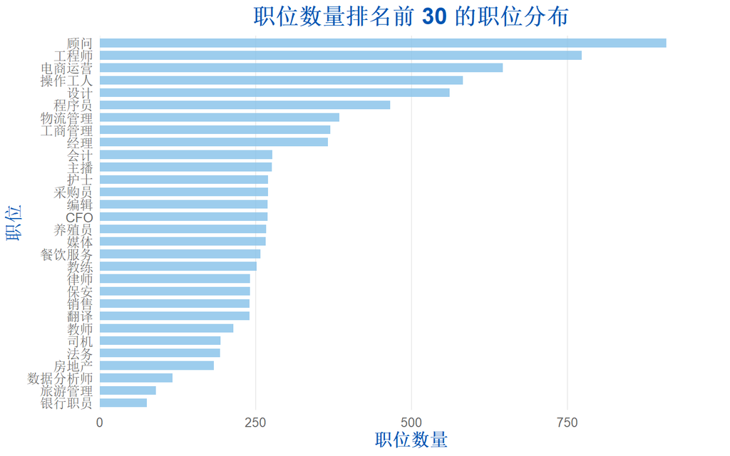

```r
# 对职位统计职位数
job_summary <- data_raw %>%
  group_by(职位) %>%
  summarise(
    职位数量 = n(),
    平均年薪 = mean(年薪, na.rm = TRUE),
    中位年薪 = median(年薪, na.rm = TRUE)
  ) %>%
  arrange(desc(职位数量))

# 只显示职位数量排名前30的职位
top_jobs <- job_summary %>% slice_head(n = 30)

# 绘制职位数量排名前30的柱状图
ggplot(top_jobs, aes(x = reorder(职位, 职位数量), y = 职位数量)) +
  geom_bar(stat = "identity", fill = "#85C1E9", alpha = 0.8, width = 0.7) +
  coord_flip() +
  labs(
    title = "职位数量排名前 30 的职位分布",
    x = "职位",
    y = "职位数量"
  ) +
  theme_minimal() +
  theme(
    text = element_text(family = theme_font),
    plot.title = element_text(size = 18, hjust = 0.5, face = "bold", color = "#0056b3"),
    axis.title.x = element_text(size = 14, face = "bold", color = "#0056b3"),
    axis.title.y = element_text(size = 14, face = "bold", color = "#0056b3"),
    axis.text.x = element_text(size = 10, color = "#666666"),
    axis.text.y = element_text(size = 10, color = "#666666"),
    panel.grid.major.y = element_blank(),
    panel.grid.minor = element_blank()
  ) +
  scale_y_continuous(expand = expansion(mult = c(0, 0.1)))
```

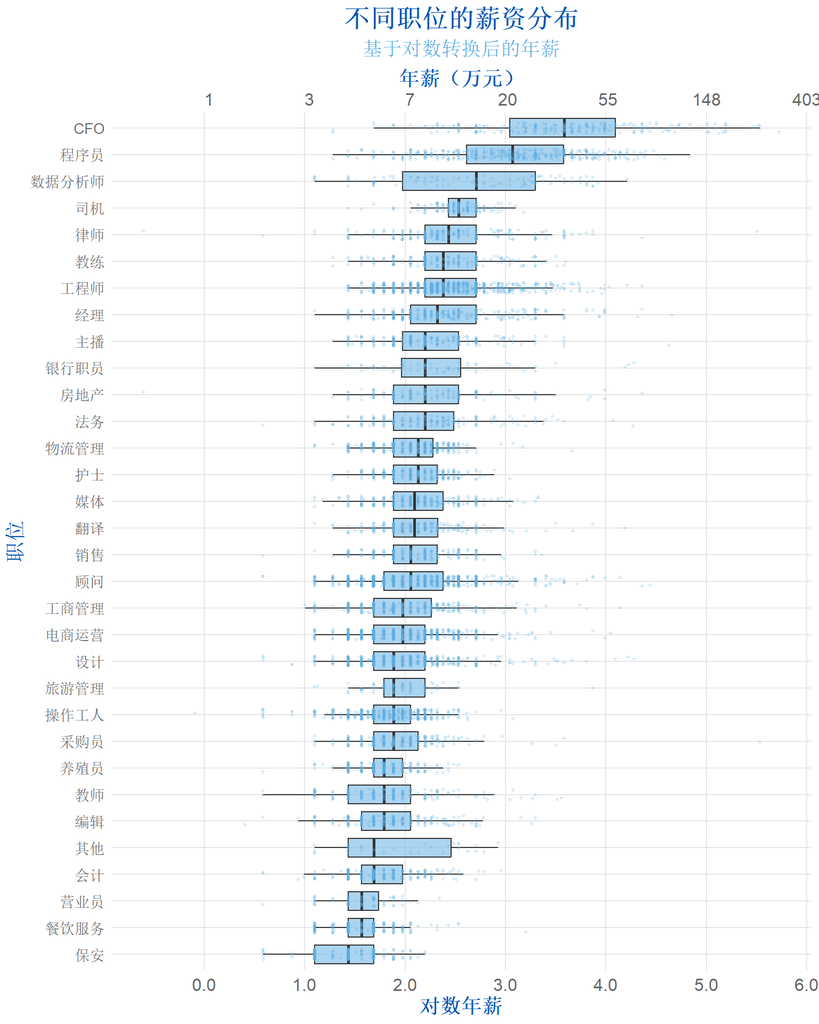

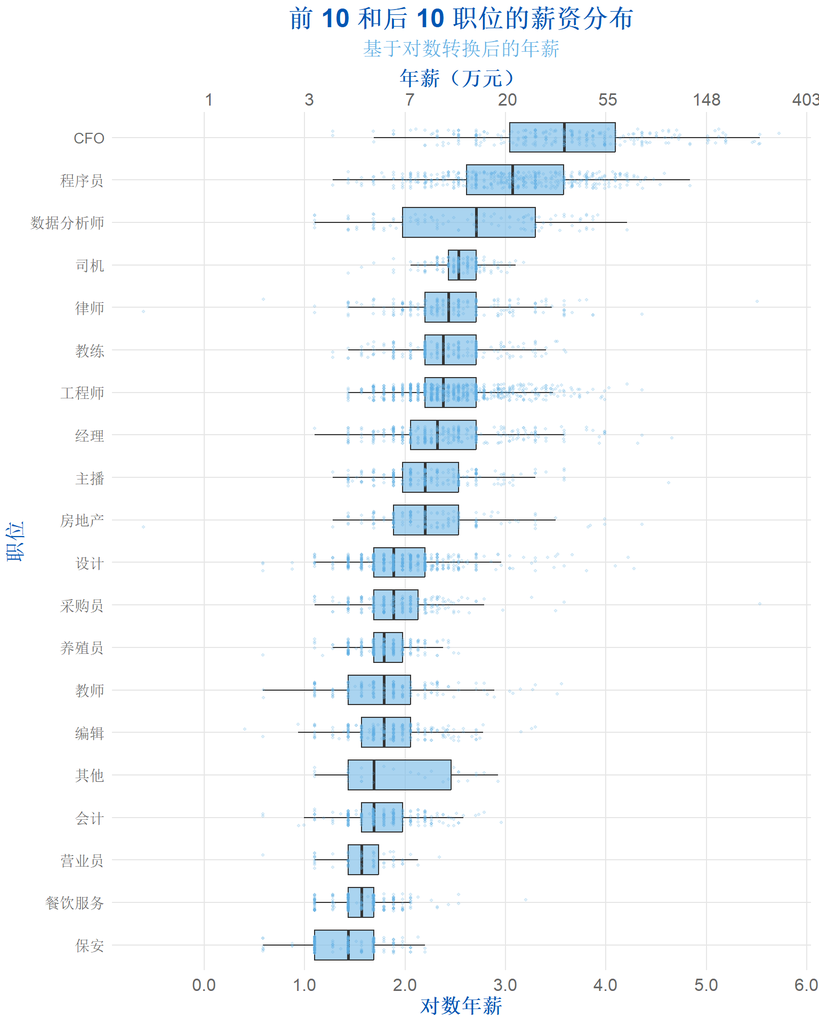

### 2.3.4 x3=福利

```r
# 描述性统计
work_experience_summary <- data_raw %>%
  group_by(福利) %>%
  summarise(
    职位数量 = n(),
    平均年薪 = mean(年薪, na.rm = TRUE),
    中位年薪 = median(年薪, na.rm = TRUE)
  ) %>%
  arrange(desc(职位数量))
print(work_experience_summary)
```

```
## # A tibble: 2 × 4
##   福利  职位数量 平均年薪 中位年薪
##   <lgl>    <int>    <dbl>    <dbl>
## 1 FALSE     5885     9.30      7.2
## 2 TRUE      3980    14.2       9.6
```

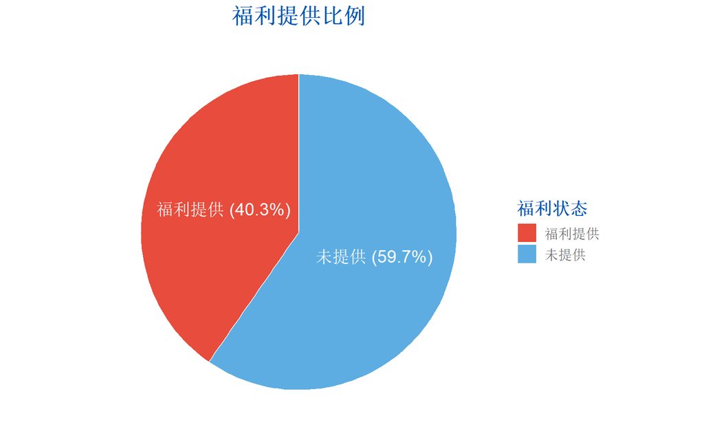

```r
# 对福利列进行统计
welfare_summary <- data_raw %>%
  summarise(
    福利提供 = sum(福利 == TRUE, na.rm = TRUE),
    未提供 = sum(福利 == FALSE, na.rm = TRUE)
  ) %>%
  pivot_longer(cols = everything(), names_to = "福利状态", values_to = "数量") %>%
  mutate(
    比例 = 数量 / sum(数量),
    标签 = paste0(福利状态, " (", scales::percent(比例, accuracy = 0.1), ")")
  )

# 绘制饼图
p4 <- ggplot(welfare_summary, aes(x = "", y = 比例, fill = 福利状态)) +
  geom_bar(stat = "identity", width = 1, color = "white") +
  coord_polar("y", start = 0) +
  labs(
    title = "福利提供比例",
    fill = "福利状态"
  ) +
  theme_minimal() +
  theme(
    text = element_text(family = theme_font),
    plot.title = element_text(size = 18, hjust = 0.5, face = "bold", color = "#0056b3"),
    legend.title = element_text(size = 14, face = "bold", color = "#0056b3"),
    legend.text = element_text(size = 12, color = "#666666"),
    axis.text = element_blank(),
    axis.title = element_blank(),
    panel.grid = element_blank()
  ) +
  scale_fill_manual(values = c("#E74C3C", "#5DADE2")) + # 设置蓝色系配色
  geom_text(
    aes(label = 标签),
    position = position_stack(vjust = 0.5),
    family = theme_font,
    size = 5,
    color = "white"
  )

# 打印图形
print(p4)
```

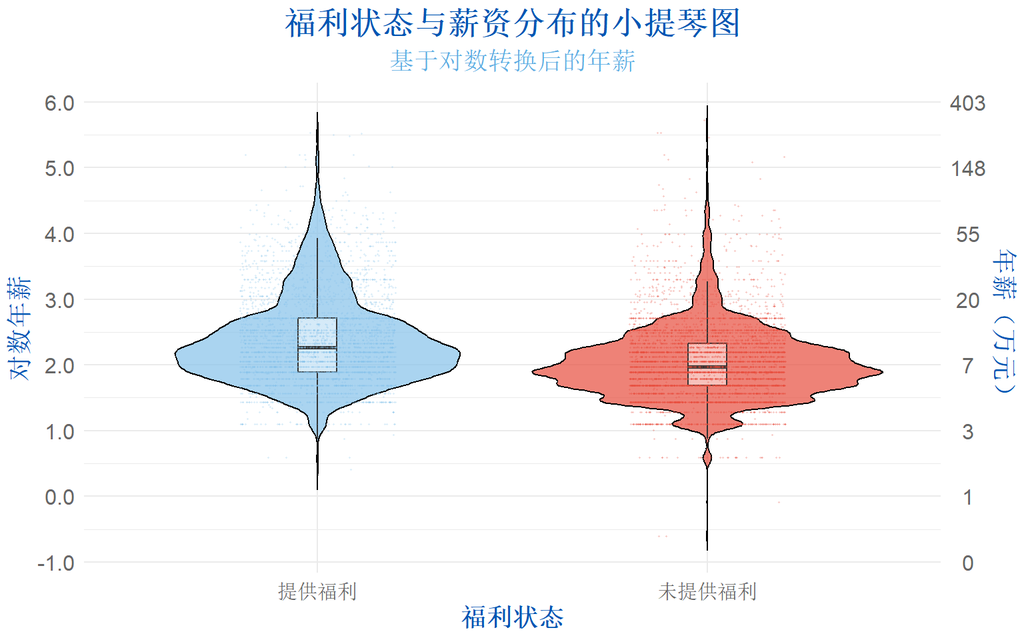

```r
# 创建福利状态列
data_raw <- data_raw %>%
  mutate(福利状态 = ifelse(福利, "提供福利", "未提供福利"))

# 绘制小提琴图
ggplot(data_raw, aes(x = 福利状态, y = log_salary, fill = 福利状态)) +
  geom_violin(alpha = 0.7, color = "black", trim = FALSE) + # 小提琴图
  geom_boxplot(width = 0.1, fill = "white", alpha = 0.5, outlier.shape = NA) + # 添加嵌套箱线图
  geom_jitter(
    aes(color = 福利状态),
    alpha = 0.2,
    width = 0.2,
    size = 0.2
  ) + # 添加散点
  scale_fill_manual(values = c("提供福利" = "#85C1E9", "未提供福利" = "#E74C3C")) +
  scale_color_manual(values = c("提供福利" = "#85C1E9", "未提供福利" = "#E74C3C")) +
  labs(
    title = "福利状态与薪资分布的小提琴图",
    subtitle = "基于对数转换后的年薪",
    x = "福利状态",
    y = "对数年薪"
  ) +
  theme_minimal() +
  theme(
    text = element_text(family = theme_font),
    plot.title = element_text(size = 18, hjust = 0.5, face = "bold", color = "#0056b3"),
    plot.subtitle = element_text(size = 14, hjust = 0.5, color = "#5DADE2"),
    axis.title.x = element_text(size = 14, face = "bold", color = "#0056b3"),
    axis.title.y = element_text(size = 14, face = "bold", color = "#0056b3"),
    axis.text.x = element_text(size = 12, color = "#666666"),
    axis.text.y = element_text(size = 12, color = "#666666"),
    legend.position = "none"
  ) +
  scale_y_continuous(
    breaks = scales::pretty_breaks(n = 6), # 主坐标轴等间隔视觉距离
    labels = scales::number_format(accuracy = 0.1), # 对数坐标标签
    sec.axis = sec_axis(
      trans = ~ exp(.), # 次坐标轴转换回实际年薪
      name = "年薪（万元）",
      breaks = exp(scales::pretty_breaks(n = 6)(range(data_raw$log_salary))),
      labels = function(x) format(round(x), scientific = FALSE, big.mark = ",")
    )
  )
```

福利状态的图表分析结果如下：

### 2.3.5 x4=工作经验

```r
# 描述性统计
work_experience_summary <- data_raw %>%
  group_by(已有工作经验) %>%
  summarise(
    职位数量 = n(),
    平均年薪 = mean(年薪, na.rm = TRUE),
    中位年薪 = median(年薪, na.rm = TRUE)
  ) %>%
  arrange(desc(职位数量))

print(work_experience_summary)
```

```
## # A tibble: 5 × 4
##   已有工作经验 职位数量 平均年薪 中位年薪
##   <chr>           <int>    <dbl>    <dbl>
## 1 经验不限         3862     8.76      7.2
## 2 1-3年            3000     9.48      7.8
## 3 3-5年            1491    14.8      10.8
## 4 1年以内           820     8.11      6.6
## 5 5年以上           692    29.3      16.2
```

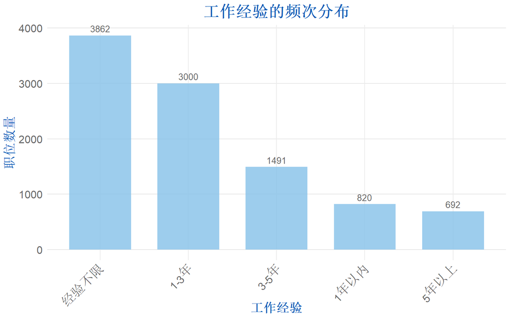

```r
# 绘制"工作经验"的频次分布图
p_frequency <- ggplot(work_experience_summary, aes(x = reorder(已有工作经验, -职位数量), y = 职位数量)) +
  geom_bar(stat = "identity", fill = "#85C1E9", alpha = 0.8, width = 0.7) +
  geom_text(aes(label = 职位数量), vjust = -0.5, size = 3.5, color = "#666666") +
  labs(
    title = "工作经验的频次分布",
    x = "工作经验",
    y = "职位数量"
  ) +
  theme_minimal() +
  theme(
    text = element_text(family = theme_font),
    plot.title = element_text(size = 18, hjust = 0.5, face = "bold", color = "#0056b3"),
    axis.title.x = element_text(size = 14, face = "bold", color = "#0056b3"),
    axis.title.y = element_text(size = 14, face = "bold", color = "#0056b3"),
    axis.text.x = element_text(size = 12, angle = 45, hjust = 1, color = "#666666"),
    axis.text.y = element_text(size = 12, color = "#666666"),
    panel.grid.major.y = element_line(color = "#E6E6E6"),
    panel.grid.minor = element_blank()
  )

print(p_frequency)
```

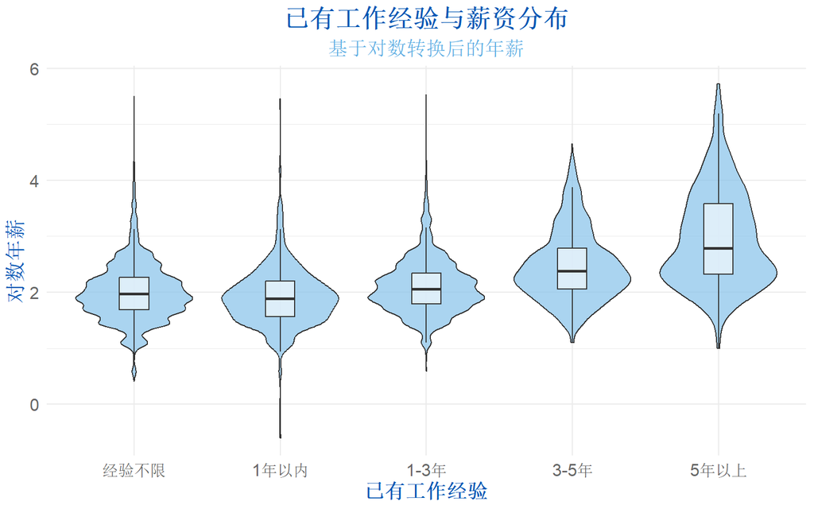

```r
# 绘制"已有工作经验"的小提琴图 + 箱线图
p_experience_salary <- ggplot(data_raw, aes(x = factor(已有工作经验, levels = c("经验不限", "1年以内", "1-3年", "3-5年", "5年以上")), y = log(年薪))) +
  geom_violin(fill = "#85C1E9", alpha = 0.7, width = 0.8, scale = "width") + # 小提琴图
  geom_boxplot(width = 0.2, fill = "white", alpha = 0.6, outlier.shape = NA) + # 箱线图

  labs(
    title = "已有工作经验与薪资分布",
    subtitle = "基于对数转换后的年薪",
    x = "已有工作经验",
    y = "对数年薪"
  ) +
  theme_minimal() +
  theme(
    text = element_text(family = theme_font),
    plot.title = element_text(size = 18, hjust = 0.5, face = "bold", color = "#0056b3"),
    plot.subtitle = element_text(size = 14, hjust = 0.5, color = "#5DADE2"),
    axis.title.x = element_text(size = 14, face = "bold", color = "#0056b3"),
    axis.title.y = element_text(size = 14, face = "bold", color = "#0056b3"),
    axis.text.x = element_text(size = 12, angle = 0, hjust = 0.5, color = "#666666"),
    axis.text.y = element_text(size = 12, color = "#666666")
  )

print(p_experience_salary)
```

### 2.3.6 x5=学历

```r
# 描述性统计
xueli_summary <- data_raw %>%
  group_by(学历) %>%
  summarise(
    职位数量 = n(),
    平均年薪 = mean(年薪, na.rm = TRUE),
    中位年薪 = median(年薪, na.rm = TRUE)
  ) %>%
  arrange(desc(职位数量))
print(xueli_summary)
```

```
## # A tibble: 5 × 4
##   学历       职位数量 平均年薪 中位年薪
##   <chr>         <int>    <dbl>    <dbl>
## 1 学历不限       3157     8.58      7.2
## 2 大专           2791     8.90      7.8
## 3 本科           2353    17.2      11.0
## 4 高中及以下     1357     7.38      6.6
## 5 研究生          207    42.3      33
```

[figure not shown]

```r
# 学历分布汇总并排序
education_summary <- data_raw %>%
  group_by(学历) %>%
  summarise(
    count = n()
  ) %>%
  mutate(
    proportion = count / sum(count), # 计算比例
    学历 = factor(学历, levels = c("学历不限", "高中及以下", "大专", "本科", "研究生")) # 指定排序
  ) %>%
  arrange(学历) # 根据因子排序

# 绘制饼图
p_education_pie <- ggplot(education_summary, aes(x = "", y = proportion, fill = 学历)) +
  geom_bar(width = 1, stat = "identity", color = "white") +
  coord_polar(theta = "y") +
  labs(
    title = "学历分布比例",
    fill = "学历"
  ) +
  theme_void() +
  theme(
    text = element_text(family = theme_font),
    plot.title = element_text(size = 16, face = "bold", hjust = 0.5, color = "#0056b3"),
    legend.title = element_text(size = 12, face = "bold", color = "#0056b3"),
    legend.text = element_text(size = 10, color = "#666666")
  ) +
  scale_fill_manual(values = c("#85C1E9", "#5DADE2", "#4A90E2", "#2874A6", "#154360")) +
  geom_text(
    aes(
      label = paste0(round(proportion * 100, 1), "%"),
      y = cumsum(proportion) - proportion / 2 # 调整标注位置
    ),
    nudge_x = 0.8, # 将标注放在饼图外部
    family = theme_font,
    size = 4,
    color = "#154360" # 标注颜色
  )

# 打印饼图
print(p_education_pie)
```

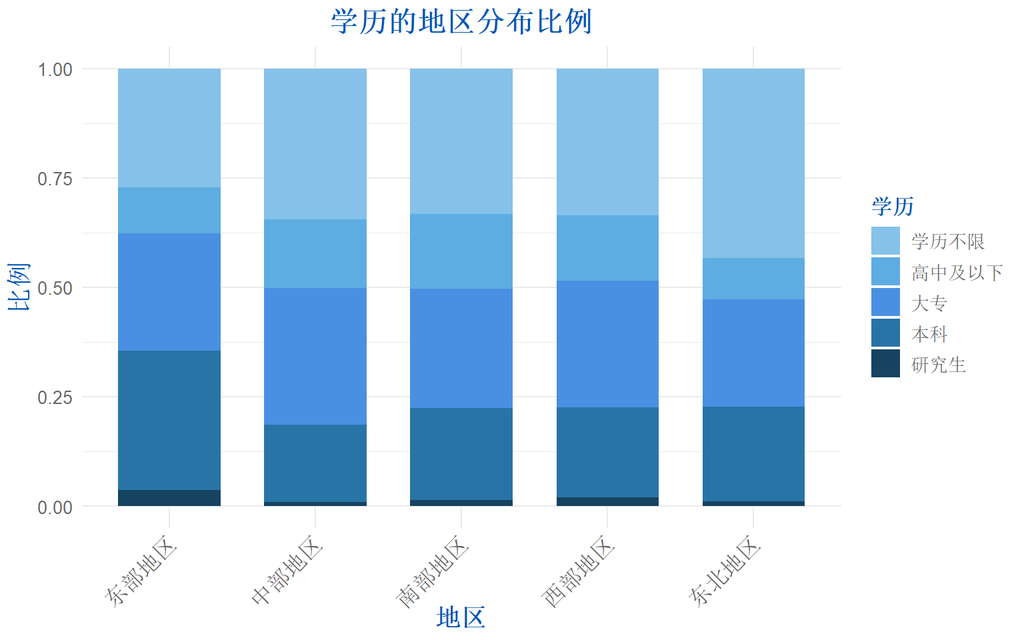

```r
# 学历的地区分布比例
education_region <- data_raw %>%
  group_by(位置, 学历) %>%
  summarise(count = n(), .groups = "drop") %>%
  group_by(位置) %>%
  mutate(proportion = count / sum(count)) %>%
  ungroup()
education_levels <- c("学历不限", "高中及以下", "大专", "本科", "研究生")
education_region$学历 <- factor(education_region$学历, levels = education_levels)

# 计算各地区的总样本数，用于排序
region_order <- education_region %>%
  group_by(位置) %>%
  summarise(total_count = sum(count), .groups = "drop") %>%
  arrange(desc(total_count))

# 设置排序顺序
education_region$位置 <- factor(education_region$位置, levels = region_order$位置)

# 绘制堆叠比例柱状图
p_education_region <- ggplot(education_region, aes(x = 位置, y = proportion, fill = 学历)) +
  geom_bar(stat = "identity", position = "stack", width = 0.7) +
  labs(
    title = "学历的地区分布比例",
    x = "地区",
    y = "比例",
    fill = "学历"
  ) +
  theme_minimal() +
  theme(
    text = element_text(family = theme_font),
    plot.title = element_text(size = 16, face = "bold", hjust = 0.5, color = "#0056b3"),
    axis.title.x = element_text(size = 14, face = "bold", color = "#0056b3"),
    axis.title.y = element_text(size = 14, face = "bold", color = "#0056b3"),
    axis.text.x = element_text(size = 10, angle = 45, hjust = 1, color = "#666666"),
    axis.text.y = element_text(size = 10, color = "#666666"),
    legend.title = element_text(size = 12, face = "bold", color = "#0056b3"),
    legend.text = element_text(size = 10, color = "#666666")
  ) +
  scale_fill_manual(
    values = c(
      "学历不限" = "#85C1E9",
      "高中及以下" = "#5DADE2",
      "大专" = "#4A90E2",
      "本科" = "#2874A6",
      "研究生" = "#154360"
    )
  )

# 打印图像
print(p_education_region)
```

学历分布比例

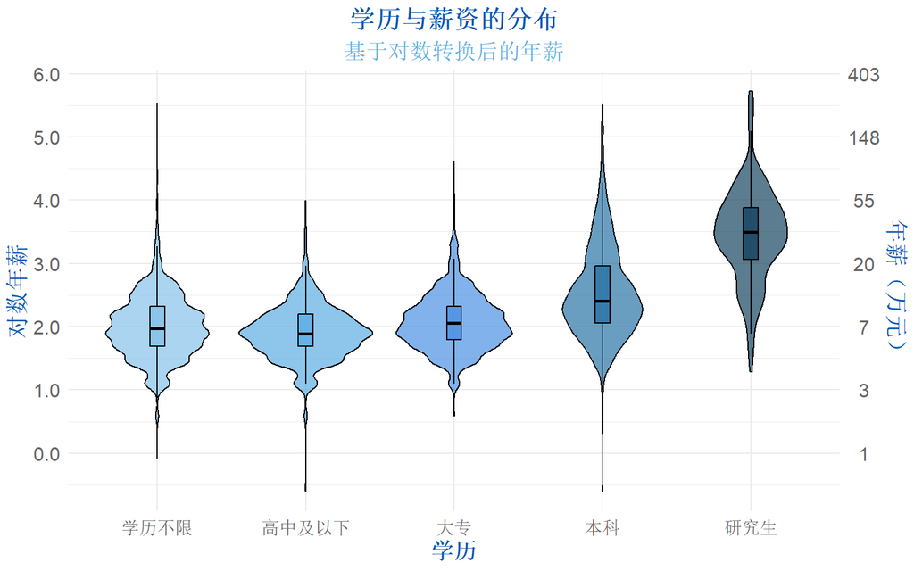

```r
# 确保学历按照固定顺序排列
education_levels <- c("学历不限", "高中及以下", "大专", "本科", "研究生")
data_raw$学历 <- factor(data_raw$学历, levels = education_levels)

# 绘制学历与对数年薪的联合图（小提琴图 + 箱线图）
p_education_salary <- ggplot(data_raw, aes(x = 学历, y = log_salary, fill = 学历)) +
  geom_violin(trim = TRUE, alpha = 0.7, color = "black") + # 小提琴图
  geom_boxplot(width = 0.1, color = "black", outlier.shape = NA, alpha = 0.8) + # 箱线图

  labs(
    title = "学历与薪资的分布",
    subtitle = "基于对数转换后的年薪",
    x = "学历",
    y = "对数年薪"
  ) +
  theme_minimal() +
  theme(
    text = element_text(family = theme_font),
    plot.title = element_text(size = 16, face = "bold", hjust = 0.5, color = "#0056b3"),
    plot.subtitle = element_text(size = 14, hjust = 0.5, color = "#5DADE2"),
    axis.title.x = element_text(size = 14, face = "bold", color = "#0056b3"),
    axis.title.y = element_text(size = 14, face = "bold", color = "#0056b3"),
    axis.text.x = element_text(size = 12, color = "#666666"),
    axis.text.y = element_text(size = 12, color = "#666666"),
    legend.position = "none" # 去掉图例
  ) +
  scale_fill_manual(
    values = c(
      "学历不限" = "#85C1E9",
      "高中及以下" = "#5DADE2",
      "大专" = "#4A90E2",
      "本科" = "#2874A6",
      "研究生" = "#154360"
    )
  ) +
  scale_y_continuous(
    breaks = scales::pretty_breaks(n = 6), # 主坐标轴等间隔视觉距离
    labels = scales::number_format(accuracy = 0.1), # 对数坐标标签
    sec.axis = sec_axis(
      trans = ~ exp(.), # 次坐标轴转换回实际年薪
      name = "年薪（万元）",
      breaks = exp(scales::pretty_breaks(n = 6)(range(data_raw$log_salary))),
      labels = function(x) format(round(x), scientific = FALSE, big.mark = ",")
    )
  )

# 打印图像
print(p_education_salary)
```

学历与薪资的分布

### 2.3.7 x6=公司行业

```r
# 描述性统计
industry_summary <- data_raw %>%
  group_by(公司行业) %>%
  summarise(
    职位数量 = n(),
    平均年薪 = mean(年薪, na.rm = TRUE),
    中位年薪 = median(年薪, na.rm = TRUE)
  ) %>%
  arrange(desc(职位数量))

print(industry_summary)
```

```
## # A tibble: 5 × 4
##   公司行业   职位数量 平均年薪 中位年薪
##   <chr>         <int>    <dbl>    <dbl>
## 1 商业服务       2940     9.45     7.73
## 2 金融互联网     2782    15.4      9
## 3 公共服务       2022     9.65     7.8
## 4 媒体教培       1238     9.47     7.2
## 5 机械制造        883    10.8      7.8
```

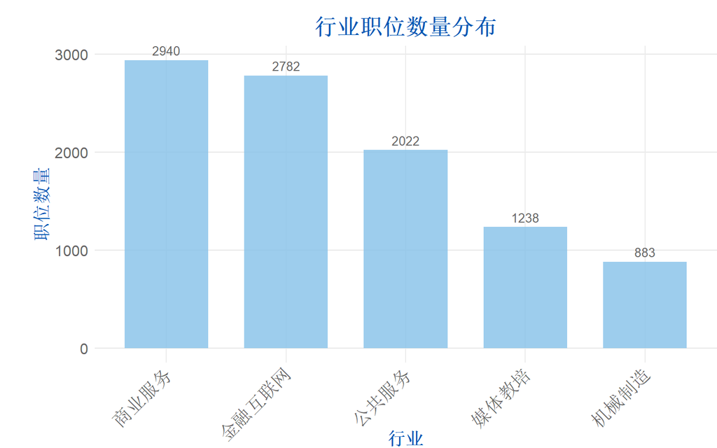

```r
# 绘制"行业"的职位数量分布柱状图
p_industry_frequency <- ggplot(industry_summary, aes(x = reorder(公司行业, -职位数量), y = 职位数量)) +
  geom_bar(stat = "identity", fill = "#85C1E9", alpha = 0.8, width = 0.7) +
  geom_text(aes(label = 职位数量), vjust = -0.5, size = 3.5, color = "#666666") +
  labs(
    title = "行业职位数量分布",
    x = "行业",
    y = "职位数量"
  ) +
  theme_minimal() +
  theme(
    text = element_text(family = theme_font),
    plot.title = element_text(size = 18, hjust = 0.5, face = "bold", color = "#0056b3"),
    axis.title.x = element_text(size = 14, face = "bold", color = "#0056b3"),
    axis.title.y = element_text(size = 14, face = "bold", color = "#0056b3"),
    axis.text.x = element_text(size = 12, angle = 45, hjust = 1, color = "#666666"),
    axis.text.y = element_text(size = 12, color = "#666666"),
    panel.grid.major.y = element_line(color = "#E6E6E6"),
    panel.grid.minor = element_blank(),
    plot.margin = unit(c(0.5, 0, 0, 1), "cm") # 增加上下左右边距
  )

print(p_industry_frequency)
```

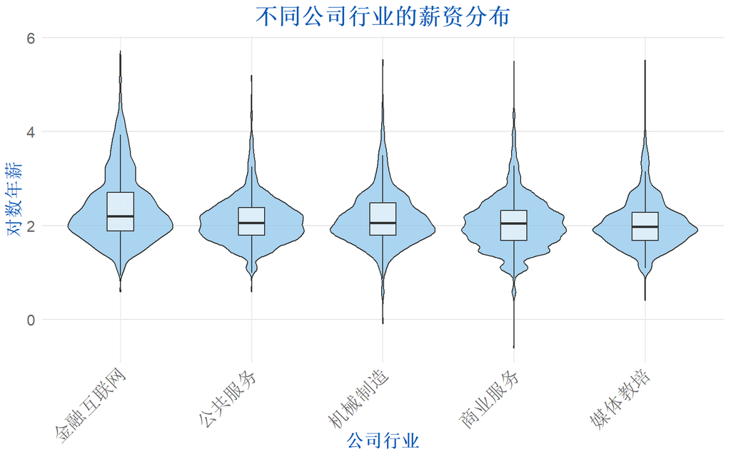

```r
# 小提琴图 + 箱线图（公司行业）
p_industry_combined <- ggplot(data_raw, aes(x = reorder(公司行业, -log_salary, FUN = median), y = log_salary)) +
  geom_violin(fill = "#85C1E9", alpha = 0.7, width = 0.8, scale = "width") + # 小提琴图
  geom_boxplot(width = 0.2, fill = "white", alpha = 0.6, outlier.shape = NA) + # 箱线图
  labs(
    title = "不同公司行业的薪资分布",
    x = "公司行业",
    y = "对数年薪"
  ) +
  theme_minimal() +
  theme(
    text = element_text(family = theme_font),
    plot.title = element_text(size = 18, hjust = 0.5, face = "bold", color = "#0056b3"),
    axis.title.x = element_text(size = 14, face = "bold", color = "#0056b3"),
    axis.title.y = element_text(size = 14, face = "bold", color = "#0056b3"),
    axis.text.x = element_text(size = 12, angle = 45, hjust = 1, color = "#666666"),
    axis.text.y = element_text(size = 12, color = "#666666"),
    panel.grid.major.y = element_line(color = "#E6E6E6"),
    panel.grid.minor = element_blank()
  )

print(p_industry_combined)
```

### 2.3.8 x7=融资阶段

```r
# 描述性统计
finance_summary <- data_raw %>%
  group_by(公司行业) %>%
  summarise(
    职位数量 = n(),
    平均年薪 = mean(年薪, na.rm = TRUE),
    中位年薪 = median(年薪, na.rm = TRUE)
  ) %>%
  arrange(desc(职位数量))

print(finance_summary)
```

```
## # A tibble: 5 × 4
##   公司行业   职位数量 平均年薪 中位年薪
##   <chr>         <int>    <dbl>    <dbl>
## 1 商业服务       2940     9.45     7.73
## 2 金融互联网     2782    15.4      9
## 3 公共服务       2022     9.65     7.8
## 4 媒体教培       1238     9.47     7.2
## 5 机械制造        883    10.8      7.8
```

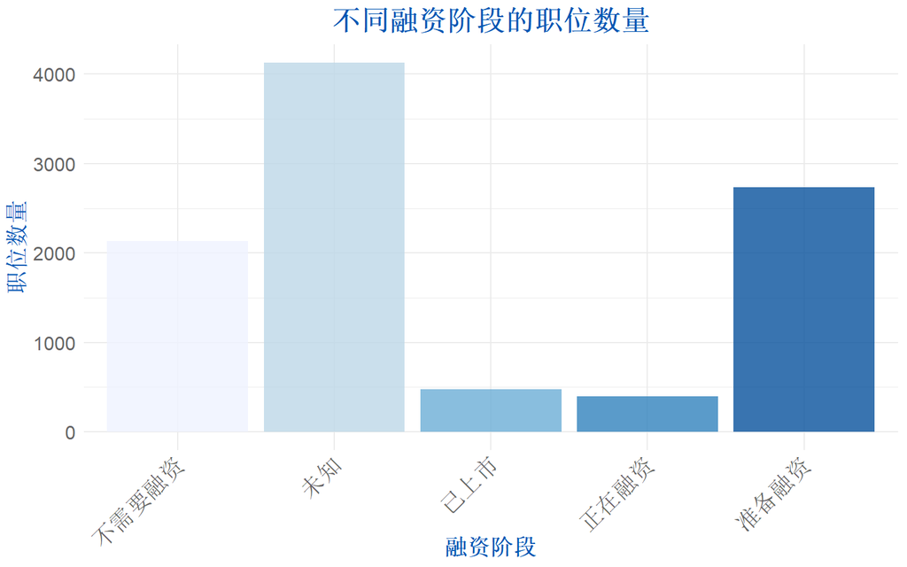

```r
# 计算融资阶段分布
finance_summary <- data_raw %>%
  group_by(融资阶段) %>%
  summarise(职位数量 = n(), 平均年薪 = mean(log(年薪), na.rm = TRUE)) %>%
  arrange(match(融资阶段, c("无需融资", "未融资", "天使轮", "A轮", "B轮", "C轮", "D轮及以上", "已上市", "未知")))

# 绘制柱状图
p_finance_bar <- ggplot(finance_summary, aes(x = 融资阶段, y = 职位数量, fill = 融资阶段)) +
  geom_bar(stat = "identity", alpha = 0.8) +
  labs(
    title = "不同融资阶段的职位数量",
    x = "融资阶段",
    y = "职位数量"
  ) +
  theme_minimal() +
  theme(
    text = element_text(family = theme_font),
    plot.title = element_text(size = 18, hjust = 0.5, face = "bold", color = "#0056b3"),
    axis.title.x = element_text(size = 14, face = "bold", color = "#0056b3"),
    axis.title.y = element_text(size = 14, face = "bold", color = "#0056b3"),
    axis.text.x = element_text(size = 12, angle = 45, hjust = 1, color = "#666666"),
    axis.text.y = element_text(size = 12, color = "#666666"),
    legend.position = "none"
  ) +
  scale_fill_brewer(palette = "Blues")

print(p_finance_bar)
```

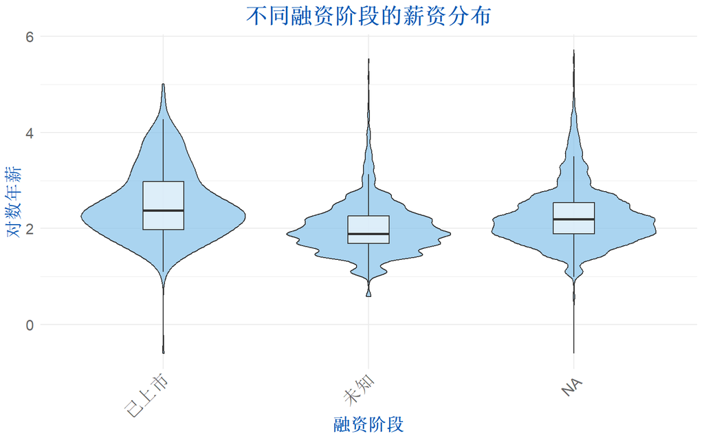

```r
# 小提琴图 + 箱线图（融资阶段）
p_finance_combined <- ggplot(data_raw, aes(x = factor(融资阶段, levels = c("无需融资", "未融资", "天使轮", "A轮", "B轮", "C轮", "D轮及以上", "已上市", "未知")), y = log(年薪))) +
  geom_violin(fill = "#85C1E9", alpha = 0.7, width = 0.8, scale = "width") + # 小提琴图
  geom_boxplot(width = 0.2, fill = "white", alpha = 0.6, outlier.shape = NA) + # 箱线图

  labs(
    title = "不同融资阶段的薪资分布",
    x = "融资阶段",
    y = "对数年薪"
  ) +
  theme_minimal() +
  theme(
    text = element_text(family = theme_font),
    plot.title = element_text(size = 18, hjust = 0.5, face = "bold", color = "#0056b3"),
    axis.title.x = element_text(size = 14, face = "bold", color = "#0056b3"),
    axis.title.y = element_text(size = 14, face = "bold", color = "#0056b3"),
    axis.text.x = element_text(size = 12, angle = 45, hjust = 1, color = "#666666"),
    axis.text.y = element_text(size = 12, color = "#666666")
  )

print(p_finance_combined)
```

```r
# 描述性统计
scale_summary <- data_raw %>%
  group_by(公司行业) %>%
  summarise(
    职位数量 = n(),
    平均年薪 = mean(年薪, na.rm = TRUE),
    中位年薪 = median(年薪, na.rm = TRUE)
  ) %>%
  arrange(desc(职位数量))

print(scale_summary)
```

```
## # A tibble: 5 × 4
##   公司行业   职位数量 平均年薪 中位年薪
##   <chr>         <int>    <dbl>    <dbl>
## 1 商业服务       2940     9.45     7.73
## 2 金融互联网     2782    15.4      9
## 3 公共服务       2022     9.65     7.8
## 4 媒体教培       1238     9.47     7.2
## 5 机械制造        883    10.8      7.8
```

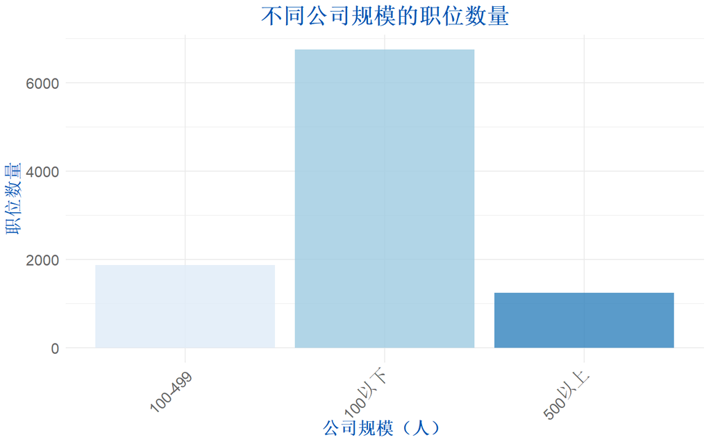

```r
# 计算公司规模分布
scale_summary <- data_raw %>%
  group_by(公司规模) %>%
  summarise(职位数量 = n(), 平均年薪 = mean(log(年薪), na.rm = TRUE)) %>%
  arrange(match(公司规模, c("100以下", "100-499", "500以上")))

# 绘制柱状图
p_scale_bar <- ggplot(scale_summary, aes(x = 公司规模, y = 职位数量, fill = 公司规模)) +
  geom_bar(stat = "identity", alpha = 0.8) +
  labs(
    title = "不同公司规模的职位数量",
    x = "公司规模（人）",
    y = "职位数量"
  ) +
  theme_minimal() +
  theme(
    text = element_text(family = theme_font),
    plot.title = element_text(size = 18, hjust = 0.5, face = "bold", color = "#0056b3"),
    axis.title.x = element_text(size = 14, face = "bold", color = "#0056b3"),
    axis.title.y = element_text(size = 14, face = "bold", color = "#0056b3"),
    axis.text.x = element_text(size = 12, angle = 45, hjust = 1, color = "#666666"),
    axis.text.y = element_text(size = 12, color = "#666666"),
    legend.position = "none"
  ) +
  scale_fill_brewer(palette = "Blues")

print(p_scale_bar)
```

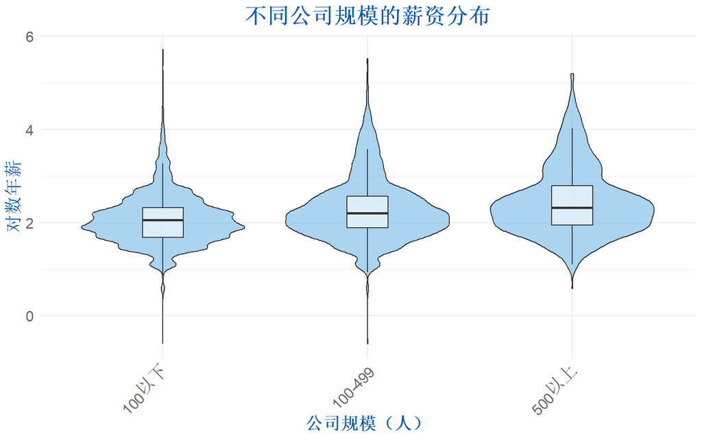

```r
# 小提琴图 + 箱线图（公司规模）
p_scale_combined <- ggplot(data_raw, aes(x = factor(公司规模, levels = c("100以下", "100-499", "500以上")), y = log(年薪))) +
  geom_violin(fill = "#85C1E9", alpha = 0.7, width = 0.8, scale = "width") + # 小提琴图
  geom_boxplot(width = 0.2, fill = "white", alpha = 0.6, outlier.shape = NA) + # 箱线图
  labs(
    title = "不同公司规模的薪资分布",
    x = "公司规模（人）",
    y = "对数年薪"
  ) +
  theme_minimal() +
  theme(
    text = element_text(family = theme_font),
    plot.title = element_text(size = 18, hjust = 0.5, face = "bold", color = "#0056b3"),
    axis.title.x = element_text(size = 14, face = "bold", color = "#0056b3"),
    axis.title.y = element_text(size = 14, face = "bold", color = "#0056b3"),
    axis.text.x = element_text(size = 12, angle = 45, hjust = 1, color = "#666666"),
    axis.text.y = element_text(size = 12, color = "#666666")
  )

print(p_scale_combined)
```

```r
# 描述性统计
job_category_summary <- data_raw %>%
  group_by(职业类别) %>%
  summarise(
    职位数量 = n(),
    平均年薪 = mean(年薪, na.rm = TRUE),
    中位年薪 = median(年薪, na.rm = TRUE)
  ) %>%
  arrange(desc(职位数量))

print(job_category_summary)
```

```
## # A tibble: 5 × 4
##   职业类别     职位数量 平均年薪 中位年薪
##   <chr>           <int>    <dbl>    <dbl>
## 1 商务与工程类     2745    18.1     10.8
## 2 销售与服务类     2536     7.97     6.6
## 3 媒体与培训类     1838     9.02     7.8
## 4 其他职业类       1404     7.49     6.6
## 5 法务与咨询类     1342    10.7      8.72
```

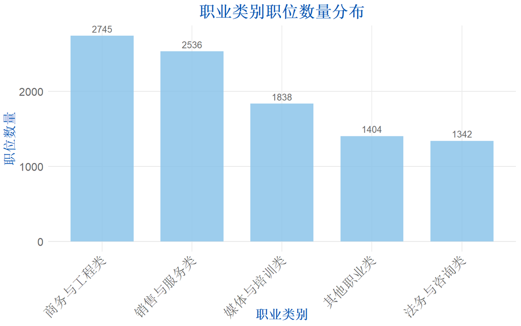

```r
# 绘制职业类别的柱状图
p_category_bar <- ggplot(job_category_summary, aes(x = reorder(职业类别, -职位数量), y = 职位数量)) +
  geom_bar(stat = "identity", fill = "#85C1E9", alpha = 0.8, width = 0.7) +
  geom_text(aes(label = 职位数量), vjust = -0.5, size = 3.5, color = "#666666") +
  labs(
    title = "职业类别职位数量分布",
    x = "职业类别",
    y = "职位数量"
  ) +
  theme_minimal() +
  theme(
    text = element_text(family = theme_font),
    plot.title = element_text(size = 18, hjust = 0.5, face = "bold", color = "#0056b3"),
    axis.title.x = element_text(size = 14, face = "bold", color = "#0056b3"),
    axis.title.y = element_text(size = 14, face = "bold", color = "#0056b3"),
    axis.text.x = element_text(size = 12, angle = 45, hjust = 1, color = "#666666"),
    axis.text.y = element_text(size = 12, color = "#666666"),
    panel.grid.major.y = element_line(color = "#E6E6E6"),
    panel.grid.minor = element_blank()
  )

print(p_category_bar)
```

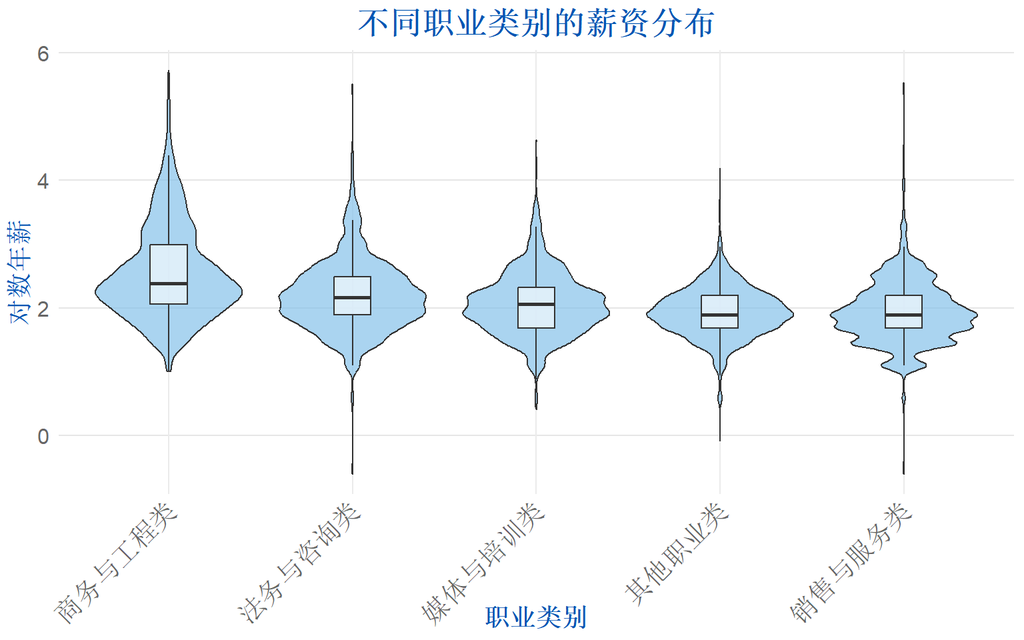

```r
# 小提琴图 + 箱线图（职业类别）
p_category_combined <- ggplot(data_raw, aes(x = reorder(职业类别, -log_salary, FUN = median), y = log_salary)) +
  geom_violin(fill = "#85C1E9", alpha = 0.7, width = 0.8, scale = "width") + # 小提琴图
  geom_boxplot(width = 0.2, fill = "white", alpha = 0.6, outlier.shape = NA) + # 箱线图
  labs(
    title = "不同职业类别的薪资分布",
    x = "职业类别",
    y = "对数年薪"
  ) +
  theme_minimal() +
  theme(
    text = element_text(family = theme_font),
    plot.title = element_text(size = 18, hjust = 0.5, face = "bold", color = "#0056b3"),
    axis.title.x = element_text(size = 14, face = "bold", color = "#0056b3"),
    axis.title.y = element_text(size = 14, face = "bold", color = "#0056b3"),
    axis.text.x = element_text(size = 12, angle = 45, hjust = 1, color = "#666666"),
    axis.text.y = element_text(size = 12, color = "#666666"),
    panel.grid.major.y = element_line(color = "#E6E6E6"),
    panel.grid.minor = element_blank()
  )

print(p_category_combined)
```

# 3 回归分析

## 3.1 加载包

```r
library(readxl)
library(dplyr)
library(writexl)
library(StepReg)
library(lmtest)
library(ggplot2)
library(leaps)
library(car)
library(lmtest)
library(DT)
```

## 3.2 读取数据

```r
salary <- read_excel("data/data.xlsx")
summary(salary)
```

```
##      职位               位置                年薪             福利
##  Length:9865        Length:9865        Min.   :  0.5475   Mode :logical
##  Class :character   Class :character   1st Qu.:  6.0000   FALSE:5885
##  Mode  :character   Mode  :character   Median :  7.8000   TRUE :3980
##                                        Mean   : 11.2779
##                                        3rd Qu.: 12.0000
##                                        Max.   :306.0000
##  已有工作经验           学历             公司行业           融资阶段
##  Length:9865        Length:9865        Length:9865        Length:9865
##  Class :character   Class :character   Class :character   Class :character
##  Mode  :character   Mode  :character   Mode  :character   Mode  :character
##
##
##
##    公司规模           职业类别           log_salary
##  Length:9865        Length:9865        Min.   :-0.6024
##  Class :character   Class :character   1st Qu.: 1.7918
##  Mode  :character   Mode  :character   Median : 2.0541
##                                        Mean   : 2.1651
##                                        3rd Qu.: 2.4849
##                                        Max.   : 5.7236
```

## 3.3 处理数据

```r
# 公司规模哑变量赋值
df1 <- data.frame(salary$公司规模)
df1 <- factor(df1, levels = c("100以下", "100-499", "500以上"))
dummy_scale <- model.matrix(~ salary$公司规模 - 1, data = salary)
salary <- cbind(salary, dummy_scale)
salary <- subset(salary, select = -公司规模)
```

```r
# 已有工作经验哑变量赋
df2 <- data.frame(salary$已有工作经验)
df2 <- factor(df2, levels = c("1年以内", "1-3年", "3-5年", "5年以上", "经验不限"))
dummy_experience <- model.matrix(~ salary$已有工作经验 - 1, data = salary)
salary <- cbind(salary, dummy_experience)
salary <- subset(salary, select = -已有工作经验)
```

```r
# 学历哑变量赋值
df3 <- data.frame(salary$学历)
df3 <- factor(df3, levels = c("本科", "高中及以下", "大专", "研究生", "学历不限"))
dummy_degree <- model.matrix(~ salary$学历 - 1, data = salary)
salary <- cbind(salary, dummy_degree)
salary <- subset(salary, select = -学历)
```

```r
# 融资阶段哑变量赋值
df4 <- data.frame(salary$学历)
df4 <- factor(df4, levels = c("不需要融资", "准备融资", "正在融资", "已上市", "未知"))
dummy_phase <- model.matrix(~ salary$融资阶段 - 1, data = salary)
salary <- cbind(salary, dummy_phase)
salary <- subset(salary, select = -融资阶段)
```

```r
# 福利哑变量赋值
salary <- salary %>%
  mutate(福利 = case_when(
    福利 == TRUE ~ 1,
    福利 == FALSE ~ 0,
    TRUE ~ 福利
  ))
salary$福利 <- as.integer(salary$福利)
```

```r
# 位置哑变量赋值
df5 <- data.frame(salary$位置)
df5 <- factor(df5, levels = c("东部地区", "中部地区", "南部地区", "西部地区", "未知"))
dummy_location <- model.matrix(~ salary$位置 - 1, data = salary)
salary <- cbind(salary, dummy_location)
salary <- subset(salary, select = -位置)
```

```r
# 公司行业哑变量赋值
df6 <- data.frame(salary$公司行业)
df6 <- factor(df6, levels = c("金融互联网", "公共服务", "机械制造", "媒体教培", "商业服务"))
dummy_industry <- model.matrix(~ salary$公司行业 - 1, data = salary)
salary <- cbind(salary, dummy_industry)
salary <- subset(salary, select = -公司行业)
```

```r
# 职业类别哑变量赋值
df7 <- data.frame(salary$公司行业)
df7 <- factor(df7, levels = c("商务与工程类", "法务与咨询类", "媒体与培训类", "销售与服务类", "其他职业类"))
dummy_category <- model.matrix(~ salary$职业类别 - 1, data = salary)

# 处理表格
salary <- subset(salary, select = -职业类别)
salary <- subset(salary, select = -职位)
salary <- subset(salary, select = -年薪)
salary <- subset(salary, select = -`salary$公司规模100-499`)
salary <- subset(salary, select = -`salary$已有工作经验1-3年`)
salary <- subset(salary, select = -`salary$融资阶段未知`)
salary <- subset(salary, select = -`salary$位置中部地区`)
salary <- subset(salary, select = -`salary$公司行业媒体教培`)
salary <- subset(salary, select = -`salary$学历本科`)
colnames(salary) <- gsub("\\$", "_", colnames(salary))
```

## 3.4 回归

```r
myfit0 <- lm(log_salary ~ ., data = salary)
summary(myfit0)
```

```
##
## Call:
## lm(formula = log_salary ~ ., data = salary)
##
## Residuals:
##     Min      1Q  Median      3Q     Max
## -2.7403 -0.3101 -0.0337  0.2738  3.7675
##
## Coefficients:
##                             Estimate Std. Error t value Pr(>|t|)
## (Intercept)                  2.13599    0.02434  87.772  < 2e-16 ***
## 福利                         0.08534    0.01204   7.090 1.43e-12 ***
## salary_公司规模100以下      -0.06062    0.01307  -4.638 3.57e-06 ***
## salary_公司规模500以上       0.08597    0.01899   4.526 6.07e-06 ***
## salary_已有工作经验1年以内  -0.19340    0.01905 -10.150  < 2e-16 ***
## `salary_已有工作经验3-5年`   0.24808    0.01550  16.002  < 2e-16 ***
## salary_已有工作经验5年以上   0.62635    0.02092  29.944  < 2e-16 ***
## salary_已有工作经验经验不限 -0.05690    0.01272  -4.473 7.81e-06 ***
## salary_学历大专             -0.29960    0.01394 -21.494  < 2e-16 ***
## salary_学历高中及以下       -0.34072    0.01764 -19.312  < 2e-16 ***
## salary_学历学历不限         -0.22036    0.01538 -14.326  < 2e-16 ***
## salary_学历研究生            0.73936    0.03527  20.960  < 2e-16 ***
## salary_融资阶段不需要融资    0.07666    0.01394   5.500 3.89e-08 ***
## salary_融资阶段已上市        0.09692    0.02764   3.507 0.000455 ***
## salary_融资阶段正在融资      0.27516    0.02769   9.937  < 2e-16 ***
## salary_融资阶段准备融资      0.06055    0.01324   4.572 4.90e-06 ***
## salary_位置东北地区         -0.05659    0.02356  -2.402 0.016346 *
## salary_位置东部地区          0.22963    0.01267  18.131  < 2e-16 ***
## salary_位置南部地区          0.09550    0.01421   6.723 1.89e-11 ***
## salary_位置西部地区          0.05430    0.01658   3.275 0.001061 **
## salary_公司行业公共服务     -0.01159    0.01767  -0.656 0.512114
## salary_公司行业机械制造     -0.03649    0.02151  -1.696 0.089935 .
## salary_公司行业金融互联网    0.11441    0.01685   6.788 1.20e-11 ***
## salary_公司行业商业服务     -0.03427    0.01651  -2.076 0.037917 *
## ---
## Signif. codes:  0 '***' 0.001 '**' 0.01 '*' 0.05 '.' 0.1 ' ' 1
##
## Residual standard error: 0.481 on 9841 degrees of freedom
## Multiple R-squared:  0.4019, Adjusted R-squared:  0.4005
## F-statistic: 287.5 on 23 and 9841 DF,  p-value: < 2.2e-16
```

### 3.4.1 残差图

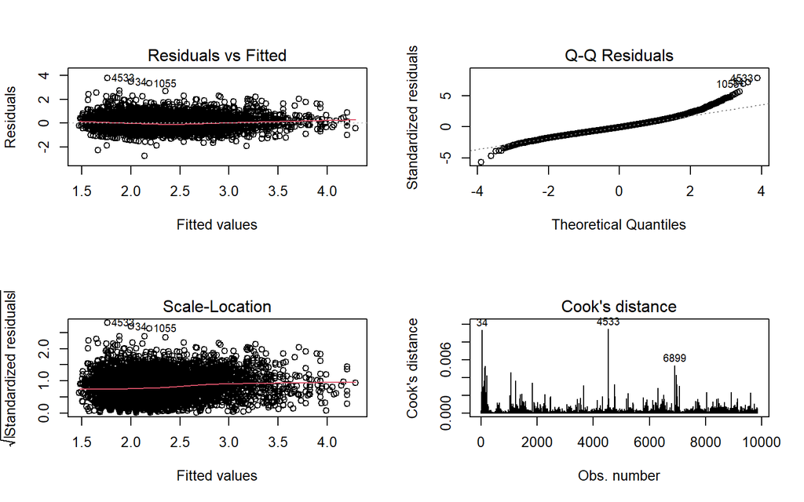

```r
par(mfrow = c(2, 2))
plot(myfit0, c(1:4))
```

```r
par(mfrow = c(1, 1))
```

### 3.4.2 异方差检验

#### 3.4.2.1 Spearman Test

对每一个自变量$x_i$与残差的绝对值两两检验。

```r
p <- rep(1, ncol(salary)) # 初始化

for (i in seq_along(p)) {
  if (colnames(salary)[i] != "log_salary") {
    p[i] <- cor.test(as.numeric(salary[, i]), abs(myfit0$residuals))$p.value
  }
}

names(p) <- colnames(salary)
p <= 0.1
##                        福利                  log_salary
##                        TRUE                       FALSE
##      salary_公司规模100以下      salary_公司规模500以上
##                        TRUE                        TRUE
##  salary_已有工作经验1年以内    salary_已有工作经验3-5年
##                       FALSE                       FALSE
##  salary_已有工作经验5年以上 salary_已有工作经验经验不限
##                        TRUE                       FALSE
##             salary_学历大专       salary_学历高中及以下
##                        TRUE                        TRUE
##         salary_学历学历不限           salary_学历研究生
##                       FALSE                        TRUE
##   salary_融资阶段不需要融资       salary_融资阶段已上市
##                       FALSE                       FALSE
##     salary_融资阶段正在融资     salary_融资阶段准备融资
##                        TRUE                       FALSE
##         salary_位置东北地区         salary_位置东部地区
##                       FALSE                        TRUE
##         salary_位置南部地区         salary_位置西部地区
##                       FALSE                        TRUE
##     salary_公司行业公共服务     salary_公司行业机械制造
##                        TRUE                        TRUE
##   salary_公司行业金融互联网     salary_公司行业商业服务
##                        TRUE                        TRUE
```

可见，存在$p<0.1$，即存在异方差问题。

> 注：书本只有一元回归的检验方法，此处增加了多元回归的异方差检验方法如下。

#### 3.4.2.2 Breusch-Pagan Test

使用**Breusch-Pagan Test**进行检验[^1]。

$$H_0:\{模型myfit0不存在异方差现象\}$$

```r
bptest(myfit0)
##
##  studentized Breusch-Pagan test
##
## data:  myfit0
## BP = 309.67, df = 23, p-value < 2.2e-16
```

由于$p<0.05$，于是在95%的置信水平下拒绝原假设，认为存在异方差问题。

### 3.4.3 自相关检验

#### 3.4.3.1 绘图

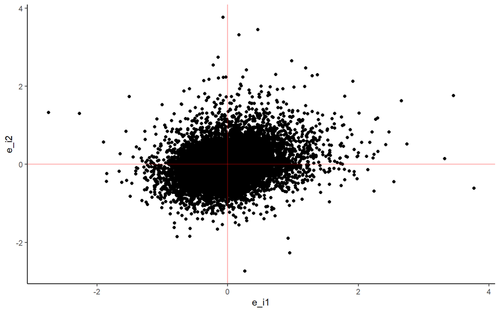

```r
n <- nrow(salary)
e_i1 <- myfit0$residuals[1:(n - 1)]
e_i2 <- myfit0$residuals[2:n]

ggplot() +
  geom_point(mapping = aes(x = e_i1, y = e_i2)) +
  geom_vline(xintercept = 0, col = "red", alpha = 0.4) +
  geom_hline(yintercept = 0, col = "red", alpha = 0.4) +
  theme_classic()
```

点无规则地落在坐标原点四周，无明显规律性。

#### 3.4.3.2 DW检验

```r
dwtest(myfit0, alternative = "two.sided")
##
##  Durbin-Watson test
##
## data:  myfit0
## DW = 1.469, p-value < 2.2e-16
## alternative hypothesis: true autocorrelation is not 0
```

可见，在95%置信水平下**拒绝**原假设。即认为存在一阶自相关性。

### 3.4.4 多重共线性检验

```r
cor(salary)
```

```
##                                    福利   log_salary salary_公司规模100以下
## 福利                         1.00000000  0.271631823           -0.294601288
## log_salary                   0.27163182  1.000000000           -0.208210239
## salary_公司规模100以下      -0.29460129 -0.208210239            1.000000000
## salary_公司规模500以上       0.25300894  0.182908378           -0.560086019
## salary_已有工作经验1年以内  -0.01633610 -0.121584230            0.011725890
## salary_已有工作经验3-5年     0.09314194  0.209850269           -0.052578087
## salary_已有工作经验5年以上   0.08803642  0.351711189           -0.094417396
## salary_已有工作经验经验不限 -0.11477263 -0.208607923            0.051425679
## salary_学历大专              0.04540677 -0.097359912           -0.018879167
## salary_学历高中及以下       -0.08487198 -0.167833142            0.038849260
## salary_学历学历不限         -0.20139793 -0.182307790            0.114333996
## salary_学历研究生            0.09296572  0.304724588           -0.084694110
## salary_融资阶段不需要融资    0.15486318  0.032464856           -0.067295129
## salary_融资阶段已上市        0.21172196  0.128359211           -0.290410064
## salary_融资阶段正在融资      0.16845252  0.211334794           -0.163867036
## salary_融资阶段准备融资      0.23610279  0.052475862           -0.030847042
## salary_位置东北地区         -0.03613087 -0.074920423            0.031364938
## salary_位置东部地区          0.14046713  0.248794759           -0.048067329
## salary_位置南部地区         -0.02014361 -0.020898579           -0.009431813
## salary_位置西部地区         -0.03176222 -0.060196187            0.023421483
## salary_公司行业公共服务     -0.01063075 -0.043901336           -0.045779657
## salary_公司行业机械制造      0.01429981 -0.003193947           -0.016250768
## salary_公司行业金融互联网    0.17982533  0.217425925           -0.091039798
## salary_公司行业商业服务     -0.13829568 -0.123675228            0.035784062
##                             salary_公司规模500以上 salary_已有工作经验1年以内
## 福利                                   0.253008938               -0.016336097
## log_salary                             0.182908378               -0.121584230
## salary_公司规模100以下                -0.560086019                0.011725890
## salary_公司规模500以上                 1.000000000                0.004802939
## salary_已有工作经验1年以内             0.004802939                1.000000000
## salary_已有工作经验3-5年               0.034515145               -0.127050092
## salary_已有工作经验5年以上             0.048405335               -0.082698949
## salary_已有工作经验经验不限           -0.010113433               -0.241504153
## salary_学历大专                       -0.023568598                0.025276697
## salary_学历高中及以下                 -0.022613567                0.048189433
## salary_学历学历不限                   -0.096169411               -0.042046369
## salary_学历研究生                      0.046468891                0.014842746
## salary_融资阶段不需要融资              0.029720500                0.012067857
## salary_融资阶段已上市                  0.444503964                0.011177704
```

[output cut: 245 more lines]

```
## salary_学历高中及以下                   0.029973080
## salary_学历学历不限                     0.085108561
## salary_学历研究生                      -0.061372654
## salary_融资阶段不需要融资              -0.001226923
## salary_融资阶段已上市                  -0.060623774
## salary_融资阶段正在融资                -0.081728058
## salary_融资阶段准备融资                -0.044815236
## salary_位置东北地区                    -0.003755652
## salary_位置东部地区                    -0.089119395
## salary_位置南部地区                     0.025348382
## salary_位置西部地区                     0.030306836
## salary_公司行业公共服务                -0.330836368
## salary_公司行业机械制造                -0.204294937
## salary_公司行业金融互联网              -0.408351089
## salary_公司行业商业服务                 1.000000000
```

```r
alias(myfit0, complete = TRUE) # 完全多重共线性
## Model :
## log_salary ~ 福利 + salary_公司规模100以下 + salary_公司规模500以上 +
##     salary_已有工作经验1年以内 + `salary_已有工作经验3-5年` +
##     salary_已有工作经验5年以上 + salary_已有工作经验经验不限 +
##     salary_学历大专 + salary_学历高中及以下 + salary_学历学历不限 +
##     salary_学历研究生 + salary_融资阶段不需要融资 +
##     salary_融资阶段已上市 + salary_融资阶段正在融资 +
##     salary_融资阶段准备融资 + salary_位置东北地区 +
##     salary_位置东部地区 + salary_位置南部地区 + salary_位置西部地区 +
##     salary_公司行业公共服务 + salary_公司行业机械制造 +
##     salary_公司行业金融互联网 + salary_公司行业商业服务

sort(vif(myfit0), decreasing = TRUE) # 多重共线性
##   salary_公司行业金融互联网     salary_公司行业商业服务
##                    2.452454                    2.430428
##         salary_学历学历不限     salary_公司行业公共服务
##                    2.195140                    2.170352
##      salary_公司规模500以上             salary_学历大专
##                    1.698292                    1.680579
## salary_已有工作经验经验不限     salary_公司行业机械制造
##                    1.643634                    1.608231
##       salary_学历高中及以下      salary_公司规模100以下
##                    1.574460                    1.573962
##         salary_位置东部地区     salary_融资阶段准备融资
##                    1.551387                    1.497824
##       salary_融资阶段已上市                        福利
##                    1.492376                    1.486591
##   salary_融资阶段不需要融资         salary_位置南部地区
##                    1.404609                    1.404196
##  `salary_已有工作经验3-5年`         salary_位置西部地区
##                    1.314766                    1.282671
##     salary_融资阶段正在融资  salary_已有工作经验5年以上
##                    1.250469                    1.216750
##  salary_已有工作经验1年以内         salary_位置东北地区
##                    1.179776                    1.136955
##           salary_学历研究生
##                    1.089855

mean(vif(myfit0))
## [1] 1.579816
```

## 3.6 对数回归

### 3.6.1 模型选择

采用**逐步回归**的方法，在不同的准则下选择变量。

先考虑 $R_{adjust}^2$准则：

```r
salary.r2adj <- leaps(x = salary[, -2], y = salary[, 2], method = "adjr2")
result <- cbind(salary.r2adj$which, adjRsq = salary.r2adj$adjr2)
optimal_model_index <- which.max(salary.r2adj$adjr2)
optimal_model <- result[optimal_model_index, ]
print(optimal_model)
```

```
##        1        2        3        4        5        6        7        8
## 1.000000 1.000000 1.000000 1.000000 1.000000 1.000000 1.000000 1.000000
##        9        A        B        C        D        E        F        G
## 1.000000 1.000000 1.000000 1.000000 1.000000 1.000000 1.000000 1.000000
##        H        I        J        K        L        M        N   adjRsq
## 1.000000 1.000000 1.000000 0.000000 1.000000 1.000000 1.000000 0.400492
```

再考虑 AIC、BIC、$C_p$准则：

首先编写所需要的函数：

```r
select_model <- function(data, metric, y_name, strategy = "bidirection") {
  # data0: 数据框
  # metric: 模型选择准则 ("AIC", "BIC", "CP")
  # y_name: 因变量名称
  # strategy: 回归策略 ("forward", "backward", "bidirection", "subset")

  # 获取所有自变量名称
  total_variate <- setdiff(colnames(data), y_name)
  data_ <- data.frame(data)

  # 使用stepwise函数进行变量选择
  fit <- stepwise(
    formula = as.formula(paste(y_name, "~ .")),
    data = data_,
    type = "linear",
    strategy = strategy,
    metric = metric
  )

  # 从lm模型中提取变量
  corrected_variable_names <- gsub(
    "\\.", "-", fit[["variables"]][["Variable_name"]]
  )
  model_terms <- corrected_variable_names[-1]

  # 创建结果数据框
  result <- data.frame(
    variable = total_variate,
    selected = total_variate %in% model_terms
  )

  return(list(
    model = fit, # stepwise的完整结果
    selected_vars = model_terms, # 选中的变量
    selection_result = result # 变量选择结果表
  ))
}
```

AIC、BIC、$C_p$准则下的变量选择：

```r
aic_result <- select_model(salary, metric = "AIC", y_name = "log_salary")
bic_result <- select_model(salary, metric = "BIC", y_name = "log_salary")
cp_result <- select_model(salary, metric = "CP", y_name = "log_salary")
```

比较三种准则下的变量选择结果：

```r
# 创建比较表
comparison <- data.frame(
  variable = aic_result$selection_result$variable,
  AIC = aic_result$selection_result$selected,
  BIC = bic_result$selection_result$selected,
  CP = cp_result$selection_result$selected
)

# 显示比较结果
datatable(comparison,
  caption = "三种准则变量选择结果比较",
  options = list(scrollX = TRUE)
)
```

|  | variable | AIC | BIC | CP |
| --- | --- | --- | --- | --- |
| 1 | 福利 | True | True | True |
| 2 | salary_公司规模100以下 | True | True | True |
| 3 | salary_公司规模500以上 | True | True | True |
| 4 | salary_已有工作经验1年以内 | True | True | True |
| 5 | salary_已有工作经验3-5年 | True | True | True |
| 6 | salary_已有工作经验5年以上 | True | True | True |
| 7 | salary_已有工作经验经验不限 | True | True | True |
| 8 | salary_学历大专 | True | True | True |
| 9 | salary_学历高中及以下 | True | True | True |
| 10 | salary_学历学历不限 | True | True | True |

[output cut: 13 more lines]

在**AIC准则**、**BIC准则**和**$C_p$准则**之间，三者所选的变量相同，考虑到多重共线性并结合三个准则，确定模型为”myfit0”。

### 3.6.2 多重共线性分析

```r
sort(vif(myfit0), decreasing = TRUE) # 多重共线性
##   salary_公司行业金融互联网     salary_公司行业商业服务
##                    2.452454                    2.430428
##         salary_学历学历不限     salary_公司行业公共服务
##                    2.195140                    2.170352
##      salary_公司规模500以上             salary_学历大专
##                    1.698292                    1.680579
## salary_已有工作经验经验不限     salary_公司行业机械制造
##                    1.643634                    1.608231
##       salary_学历高中及以下      salary_公司规模100以下
##                    1.574460                    1.573962
##         salary_位置东部地区     salary_融资阶段准备融资
##                    1.551387                    1.497824
##       salary_融资阶段已上市                        福利
##                    1.492376                    1.486591
##   salary_融资阶段不需要融资         salary_位置南部地区
##                    1.404609                    1.404196
##  `salary_已有工作经验3-5年`         salary_位置西部地区
##                    1.314766                    1.282671
##     salary_融资阶段正在融资  salary_已有工作经验5年以上
##                    1.250469                    1.216750
##  salary_已有工作经验1年以内         salary_位置东北地区
##                    1.179776                    1.136955
##           salary_学历研究生
##                    1.089855

mean(vif(myfit0))
## [1] 1.579816
```

可见，$\bar{VIF}$未明显大于1，且$VIF_j<10$均成立，故可认为消除了多重共线性。

### 3.6.3 异方差检验

#### 3.6.3.1 Breusch-Pagan Test

使用**Breusch-Pagan Test**进行检验[^2]。

$$H_0:\{模型myfit0不存在异方差现象\}$$

```r
bptest(myfit0)
##
##  studentized Breusch-Pagan test
##
## data:  myfit0
## BP = 309.67, df = 23, p-value < 2.2e-16
```

### 3.6.4 自相关检验

#### 3.6.4.1 DW检验

```r
dwtest(myfit0, alternative = "two.sided")
##
##  Durbin-Watson test
##
## data:  myfit0
## DW = 1.469, p-value < 2.2e-16
## alternative hypothesis: true autocorrelation is not 0
```

### 3.6.5 正态性检验

使用**Kolmogorov-Smirnov Test**检验模型残差的正态性。

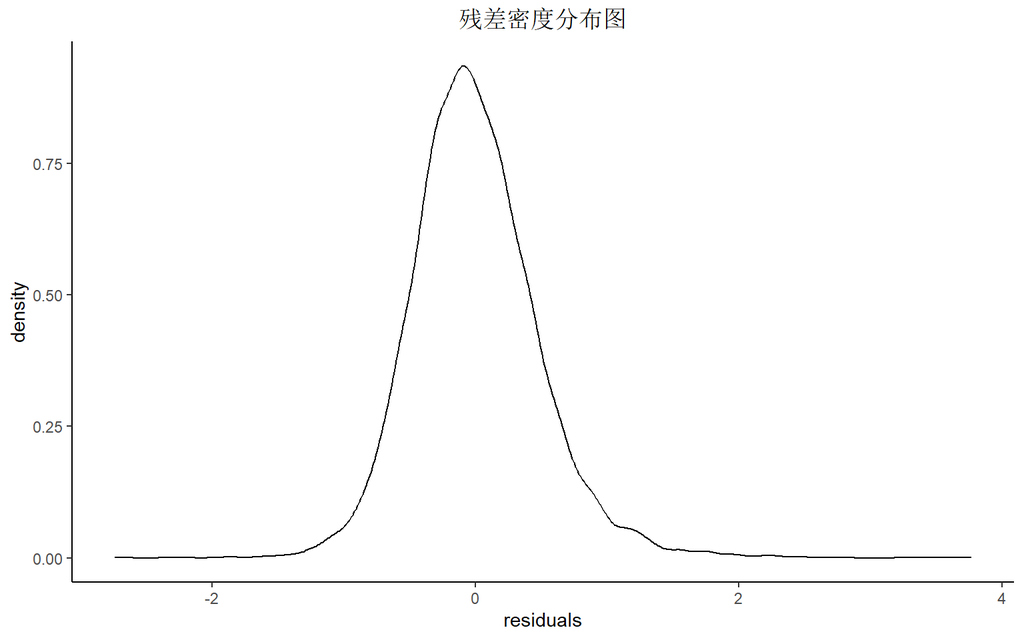

```r
ks.test(myfit0$residuals, y = pnorm, mean(myfit0$residuals), sd(myfit0$residuals))
##
##  Asymptotic one-sample Kolmogorov-Smirnov test
##
## data:  myfit0$residuals
## D = 0.040237, p-value = 2.676e-14
## alternative hypothesis: two-sided

ggplot() +
  geom_density(mapping = aes(x = myfit0$residuals)) +
  labs(title = "残差密度分布图", x = "residuals") +
  theme_classic() +
  theme(plot.title = element_text(hjust = 0.5))
```

## 3.7 模型改进

基于前面的分析，我们发现模型的调整R方为0.4005，还有提升空间。考虑到变量间可能存在交互效应，我们引入以下交叉项来改进模型：

### 3.7.1 学历与工作经验的交互

```r
myfit1 <- lm(
  log_salary ~ . +
    salary_学历大专 * salary_已有工作经验1年以内 +
    salary_学历大专 * `salary_已有工作经验3-5年` +
    salary_学历大专 * salary_已有工作经验5年以上 +
    salary_学历高中及以下 * salary_已有工作经验1年以内 +
    salary_学历高中及以下 * `salary_已有工作经验3-5年` +
    salary_学历高中及以下 * salary_已有工作经验5年以上 +
    salary_学历研究生 * salary_已有工作经验1年以内 +
    salary_学历研究生 * `salary_已有工作经验3-5年` +
    salary_学历研究生 * salary_已有工作经验5年以上,
  data = salary
)
summary(myfit1)
```

```
##
## Call:
## lm(formula = log_salary ~ . + salary_学历大专 * salary_已有工作经验1年以内 +
##     salary_学历大专 * `salary_已有工作经验3-5年` +
##     salary_学历大专 * salary_已有工作经验5年以上 +
##     salary_学历高中及以下 * salary_已有工作经验1年以内 +
##     salary_学历高中及以下 * `salary_已有工作经验3-5年` +
##     salary_学历高中及以下 * salary_已有工作经验5年以上 +
##     salary_学历研究生 * salary_已有工作经验1年以内 +
##     salary_学历研究生 * `salary_已有工作经验3-5年` +
##     salary_学历研究生 * salary_已有工作经验5年以上,
##     data = salary)
##
## Residuals:
##     Min      1Q  Median      3Q     Max
## -2.6550 -0.3097 -0.0326  0.2690  3.7609
##
## Coefficients:
##                                                   Estimate Std. Error t value
## (Intercept)                                       2.114830   0.024817  85.218
## 福利                                              0.086024   0.011968   7.188
## salary_公司规模100以下                           -0.058637   0.012999  -4.511
## salary_公司规模500以上                            0.091348   0.018893   4.835
## salary_已有工作经验1年以内                       -0.259729   0.027067  -9.596
## `salary_已有工作经验3-5年`                        0.270051   0.020946  12.892
## salary_已有工作经验5年以上                        0.741152   0.026529  27.938
## salary_已有工作经验经验不限                      -0.056974   0.012710  -4.483
## salary_学历大专                                  -0.264427   0.017148 -15.420
## salary_学历高中及以下                            -0.328461   0.019914 -16.494
## salary_学历学历不限                              -0.200840   0.015799 -12.712
## salary_学历研究生                                 0.712801   0.058050  12.279
## salary_融资阶段不需要融资                         0.077004   0.013860   5.556
## salary_融资阶段已上市                             0.093130   0.027485   3.388
## salary_融资阶段正在融资                           0.271512   0.027546   9.857
## salary_融资阶段准备融资                           0.058471   0.013168   4.440
## salary_位置东北地区                              -0.055119   0.023426  -2.353
## salary_位置东部地区                               0.228084   0.012596  18.108
## salary_位置南部地区                               0.097271   0.014122   6.888
## salary_位置西部地区                               0.050298   0.016488   3.051
## salary_公司行业公共服务                          -0.008279   0.017574  -0.471
```

[output cut: 37 more lines]

```
## salary_已有工作经验1年以内:salary_学历大专       0.087456 .
## `salary_已有工作经验3-5年`:salary_学历大专       0.292724
## salary_已有工作经验5年以上:salary_学历大专       1.03e-13 ***
## salary_已有工作经验1年以内:salary_学历高中及以下 8.39e-08 ***
## `salary_已有工作经验3-5年`:salary_学历高中及以下 0.025049 *
## salary_已有工作经验5年以上:salary_学历高中及以下 4.89e-09 ***
## salary_已有工作经验1年以内:salary_学历研究生     0.153142
## `salary_已有工作经验3-5年`:salary_学历研究生     0.454588
## salary_已有工作经验5年以上:salary_学历研究生     0.418312
## ---
## Signif. codes:  0 '***' 0.001 '**' 0.01 '*' 0.05 '.' 0.1 ' ' 1
##
## Residual standard error: 0.478 on 9832 degrees of freedom
## Multiple R-squared:  0.4099, Adjusted R-squared:  0.4079
## F-statistic: 213.4 on 32 and 9832 DF,  p-value: < 2.2e-16
```

这组交互项的理论基础是：高学历(研究生、本科)与丰富工作经验(5年以上)的组合可能带来额外的薪资溢价。

### 3.7.2 地区与行业的交互

```r
myfit2 <- lm(
  log_salary ~ . +
    salary_位置东部地区:salary_公司行业金融互联网 +
    salary_位置南部地区:salary_公司行业金融互联网,
  data = salary
)
summary(myfit2)
```

```
##
## Call:
## lm(formula = log_salary ~ . + salary_位置东部地区:salary_公司行业金融互联网 +
##     salary_位置南部地区:salary_公司行业金融互联网,
##     data = salary)
##
## Residuals:
##     Min      1Q  Median      3Q     Max
## -2.7189 -0.3104 -0.0339  0.2712  3.7486
##
## Coefficients:
##                                                Estimate Std. Error t value
## (Intercept)                                    2.150055   0.024454  87.921
## 福利                                           0.085701   0.012023   7.128
## salary_公司规模100以下                        -0.059872   0.013058  -4.585
## salary_公司规模500以上                         0.086036   0.018979   4.533
## salary_已有工作经验1年以内                    -0.192175   0.019029 -10.099
## `salary_已有工作经验3-5年`                     0.247704   0.015482  16.000
## salary_已有工作经验5年以上                     0.623857   0.020895  29.857
## salary_已有工作经验经验不限                   -0.056950   0.012703  -4.483
## salary_学历大专                               -0.297479   0.013925 -21.363
## salary_学历高中及以下                         -0.338468   0.017625 -19.204
## salary_学历学历不限                           -0.218513   0.015365 -14.222
## salary_学历研究生                              0.732004   0.035263  20.758
## salary_融资阶段不需要融资                      0.077696   0.013920   5.582
## salary_融资阶段已上市                          0.094052   0.027602   3.407
## salary_融资阶段正在融资                        0.267078   0.027695   9.643
## salary_融资阶段准备融资                        0.061340   0.013226   4.638
## salary_位置东北地区                           -0.058199   0.023533  -2.473
## salary_位置东部地区                            0.191785   0.014526  13.203
## salary_位置南部地区                            0.073172   0.016197   4.518
## salary_位置西部地区                            0.052426   0.016560   3.166
## salary_公司行业公共服务                       -0.009689   0.017655  -0.549
## salary_公司行业机械制造                       -0.032633   0.021495  -1.518
## salary_公司行业金融互联网                      0.047664   0.021063   2.263
## salary_公司行业商业服务                       -0.034625   0.016488  -2.100
## salary_位置东部地区:salary_公司行业金融互联网  0.131091   0.024378   5.377
## salary_位置南部地区:salary_公司行业金融互联网  0.087377   0.029373   2.975
##                                               Pr(>|t|)
## (Intercept)                                    < 2e-16 ***
```

[output cut: 16 more lines]

```
## salary_位置东部地区                            < 2e-16 ***
## salary_位置南部地区                           6.33e-06 ***
## salary_位置西部地区                           0.001552 **
## salary_公司行业公共服务                       0.583139
## salary_公司行业机械制造                       0.129010
## salary_公司行业金融互联网                     0.023662 *
## salary_公司行业商业服务                       0.035751 *
## salary_位置东部地区:salary_公司行业金融互联网 7.73e-08 ***
## salary_位置南部地区:salary_公司行业金融互联网 0.002939 **
## ---
## Signif. codes:  0 '***' 0.001 '**' 0.01 '*' 0.05 '.' 0.1 ' ' 1
##
## Residual standard error: 0.4803 on 9839 degrees of freedom
## Multiple R-squared:  0.4037, Adjusted R-squared:  0.4021
## F-statistic: 266.4 on 25 and 9839 DF,  p-value: < 2.2e-16
```

这组交互项基于：金融互联网行业在东部和南部发达地区可能有更高的薪资水平。

### 3.7.3 综合模型

选择显著的交互项构建最终模型：

```r
myfit_final <- lm(
  log_salary ~ . +
    salary_学历大专 * salary_已有工作经验1年以内 +
    salary_学历大专 * salary_已有工作经验5年以上 +
    salary_学历高中及以下 * salary_已有工作经验1年以内 +
    salary_学历高中及以下 * `salary_已有工作经验3-5年` +
    salary_学历高中及以下 * salary_已有工作经验5年以上 +
    salary_位置东部地区:salary_公司行业金融互联网 +
    salary_位置南部地区:salary_公司行业金融互联网,
  data = salary
)
summary(myfit_final)
```

```
##
## Call:
## lm(formula = log_salary ~ . + salary_学历大专 * salary_已有工作经验1年以内 +
##     salary_学历大专 * salary_已有工作经验5年以上 +
##     salary_学历高中及以下 * salary_已有工作经验1年以内 +
##     salary_学历高中及以下 * `salary_已有工作经验3-5年` +
##     salary_学历高中及以下 * salary_已有工作经验5年以上 +
##     salary_位置东部地区:salary_公司行业金融互联网 +
##     salary_位置南部地区:salary_公司行业金融互联网,
##     data = salary)
##
## Residuals:
##     Min      1Q  Median      3Q     Max
## -2.6225 -0.3078 -0.0325  0.2701  3.7416
##
## Coefficients:
##                                                   Estimate Std. Error t value
## (Intercept)                                       2.133615   0.024470  87.193
## 福利                                              0.086324   0.011952   7.222
## salary_公司规模100以下                           -0.057927   0.012982  -4.462
## salary_公司规模500以上                            0.090756   0.018872   4.809
## salary_已有工作经验1年以内                       -0.273508   0.026204 -10.438
## `salary_已有工作经验3-5年`                        0.258792   0.015949  16.226
## salary_已有工作经验5年以上                        0.741399   0.024929  29.740
## salary_已有工作经验经验不限                      -0.058393   0.012670  -4.609
## salary_学历大专                                  -0.271118   0.014896 -18.200
## salary_学历高中及以下                            -0.328844   0.019425 -16.929
## salary_学历学历不限                              -0.200290   0.015435 -12.976
## salary_学历研究生                                 0.724382   0.035085  20.647
## salary_融资阶段不需要融资                         0.078156   0.013842   5.646
## salary_融资阶段已上市                             0.089906   0.027441   3.276
## salary_融资阶段正在融资                           0.261774   0.027536   9.507
## salary_融资阶段准备融资                           0.059268   0.013150   4.507
## salary_位置东北地区                              -0.057754   0.023393  -2.469
## salary_位置东部地区                               0.190537   0.014440  13.195
## salary_位置南部地区                               0.074412   0.016100   4.622
## salary_位置西部地区                               0.048341   0.016466   2.936
## salary_公司行业公共服务                          -0.007247   0.017548  -0.413
## salary_公司行业机械制造                          -0.029844   0.021374  -1.396
## salary_公司行业金融互联网                         0.044732   0.020939   2.136
```

[output cut: 31 more lines]

```
## salary_公司行业金融互联网                         0.03268 *
## salary_公司行业商业服务                           0.05199 .
## salary_已有工作经验1年以内:salary_学历大专        0.02045 *
## salary_已有工作经验5年以上:salary_学历大专       2.24e-14 ***
## salary_已有工作经验1年以内:salary_学历高中及以下 1.51e-08 ***
## `salary_已有工作经验3-5年`:salary_学历高中及以下  0.03310 *
## salary_已有工作经验5年以上:salary_学历高中及以下 3.24e-09 ***
## salary_位置东部地区:salary_公司行业金融互联网    7.23e-08 ***
## salary_位置南部地区:salary_公司行业金融互联网     0.00223 **
## ---
## Signif. codes:  0 '***' 0.001 '**' 0.01 '*' 0.05 '.' 0.1 ' ' 1
##
## Residual standard error: 0.4774 on 9834 degrees of freedom
## Multiple R-squared:  0.4113, Adjusted R-squared:  0.4095
## F-statistic:   229 on 30 and 9834 DF,  p-value: < 2.2e-16
```

### 3.7.4 模型比较

比较各个模型的调整R方

```r
models <- list(
  "原始模型" = myfit0,
  "学历经验交互" = myfit1,
  "地区行业交互" = myfit2,
  "综合模型" = myfit_final
)
comparison <- sapply(models, function(x) {
  c(
    adj.r.squared = summary(x)$adj.r.squared,
    AIC = AIC(x),
    BIC = BIC(x)
  )
})

# 展示比较结果
print(round(comparison, 4))
```

```
##                 原始模型 学历经验交互 地区行业交互   综合模型
## adj.r.squared     0.4005       0.4079       0.4021     0.4095
## AIC           13582.1297   13467.3294   13556.4016 13439.2671
## BIC           13762.0484   13712.0188   13750.7138 13669.5631
```

通过引入这些交互项，我们期望能够：

- 捕捉变量间的协同效应
- 提高模型的解释力
- 更好地反映劳动力市场的复杂性

## 3.9 参考

[^1]: [How to Perform a Breusch-Pagan Test in R︎](https://www.statology.org/breusch-pagan-test-r/)
[^2]: [How to Perform a Breusch-Pagan Test in R︎](https://www.statology.org/breusch-pagan-test-r/)